# Pandemic associated changes in cognition from the CLSA Comprehensive Cohort

## 6.3) Mental Alteration Test

### 6.3.1) Model

```r
modelMAT_adj11<- lmer(MAT_Normed~ timefactor*Pandemic*Age_sex + Education + Ethnicity + IncomeLevel + BMI + CESD.10baseline + SmokingStatus + Relationshipstatus +
                            Livingstatus + Anxiety + MoodDisord + Chronicconditions + MAT_Normedbaseline +
                      (1|ID), data= Tracking.data_long_2)
summary(modelMAT_adj11)
```

```
## Linear mixed model fit by REML. t-tests use Satterthwaite's method [
## lmerModLmerTest]
## Formula:
## MAT_Normed ~ timefactor * Pandemic * Age_sex + Education + Ethnicity +
##     IncomeLevel + BMI + CESD.10baseline + SmokingStatus + Relationshipstatus +
##     Livingstatus + Anxiety + MoodDisord + Chronicconditions +
##     MAT_Normedbaseline + (1 | ID)
##    Data: Tracking.data_long_2
##
## REML criterion at convergence: 97258.2
##
## Scaled residuals:
##     Min      1Q  Median      3Q     Max
## -3.4157 -0.5134 -0.0505  0.3918  4.6109
##
## Random effects:
##  Groups   Name        Variance Std.Dev.
##  ID       (Intercept) 2.617    1.618
##  Residual             7.857    2.803
## Number of obs: 18841, groups:  ID, 10262
##
## Fixed effects:
##                                                                             Estimate
## (Intercept)                                                                8.506e+00
## timefactor2                                                               -3.390e+00
## PandemicFU2 data collected before COVID-19                                -1.609e+00
## Age_sexFemales 65+                                                        -9.236e-01
## Age_sexMales 45-64                                                        -3.457e+00
## Age_sexMales 65+                                                          -3.492e+00
## EducationHigh School Diploma                                              -1.927e-02
## EducationLess than High School Diploma                                    -1.655e-01
## EducationSome College                                                     -1.753e-01
## EthnicityWhite                                                             8.811e-01
## IncomeLevel>$150k                                                          1.679e-01
## IncomeLevel$100-150k                                                       1.954e-01
## IncomeLevel$20-50k                                                         9.886e-02
## IncomeLevel$50-100k                                                        1.481e-01
## BMI                                                                       -1.358e-02
## CESD.10baseline                                                           -1.386e-02
## SmokingStatusFormer Smoker                                                 4.959e-02
```

[output cut: 215 more lines]

```
## MoodDisordYes
## Chronicconditions                                                         **
## MAT_Normedbaseline                                                        ***
## timefactor2:PandemicFU2 data collected before COVID-19                    ***
## timefactor2:Age_sexFemales 65+                                            ***
## timefactor2:Age_sexMales 45-64                                            ***
## timefactor2:Age_sexMales 65+                                              ***
## PandemicFU2 data collected before COVID-19:Age_sexFemales 65+
## PandemicFU2 data collected before COVID-19:Age_sexMales 45-64             ***
## PandemicFU2 data collected before COVID-19:Age_sexMales 65+               ***
## timefactor2:PandemicFU2 data collected before COVID-19:Age_sexFemales 65+
## timefactor2:PandemicFU2 data collected before COVID-19:Age_sexMales 45-64 ***
## timefactor2:PandemicFU2 data collected before COVID-19:Age_sexMales 65+   ***
## ---
## Signif. codes:  0 '***' 0.001 '**' 0.01 '*' 0.05 '.' 0.1 ' ' 1
```

```
##
## Correlation matrix not shown by default, as p = 40 > 12.
## Use print(x, correlation=TRUE)  or
##     vcov(x)        if you need it
```

```r
anova(modelMAT_adj11)
```

```
## Type III Analysis of Variance Table with Satterthwaite's method
##                              Sum Sq Mean Sq NumDF   DenDF   F value    Pr(>F)
## timefactor                   5230.1  5230.1     1  9817.9  665.6614 < 2.2e-16
## Pandemic                      117.9   117.9     1 10185.2   15.0061 0.0001078
## Age_sex                      3898.4  1299.5     3 10141.0  165.3911 < 2.2e-16
## Education                      35.9    12.0     3 10043.7    1.5248 0.2058103
## Ethnicity                     232.1   232.1     1 10164.4   29.5375 5.611e-08
## IncomeLevel                    28.6     7.2     4  9964.1    0.9105 0.4566491
## BMI                            51.7    51.7     1  9851.2    6.5829 0.0103112
## CESD.10baseline                35.8    35.8     1  9960.1    4.5517 0.0329111
## SmokingStatus                  26.7     8.9     3  9942.4    1.1345 0.3335396
## Relationshipstatus            200.0    50.0     4 10062.3    6.3652 4.120e-05
## Livingstatus                   79.9    26.6     3 10044.7    3.3909 0.0171896
## Anxiety                        11.2    11.2     1  9993.4    1.4191 0.2335774
## MoodDisord                      0.1     0.1     1  9930.9    0.0080 0.9288023
## Chronicconditions              84.7    84.7     1 10095.4   10.7777 0.0010308
## MAT_Normedbaseline          25849.9 25849.9     1 10062.7 3290.0323 < 2.2e-16
## timefactor:Pandemic           716.3   716.3     1  9818.4   91.1717 < 2.2e-16
## timefactor:Age_sex           5550.9  1850.3     3  9759.5  235.4981 < 2.2e-16
## Pandemic:Age_sex              458.7   152.9     3 10146.3   19.4623 1.409e-12
## timefactor:Pandemic:Age_sex   893.1   297.7     3  9759.5   37.8895 < 2.2e-16
##
## timefactor                  ***
## Pandemic                    ***
## Age_sex                     ***
## Education
## Ethnicity                   ***
## IncomeLevel
## BMI                         *
## CESD.10baseline             *
## SmokingStatus
## Relationshipstatus          ***
## Livingstatus                *
## Anxiety
## MoodDisord
## Chronicconditions           **
## MAT_Normedbaseline          ***
## timefactor:Pandemic         ***
## timefactor:Age_sex          ***
## Pandemic:Age_sex            ***
## timefactor:Pandemic:Age_sex ***
## ---
## Signif. codes:  0 '***' 0.001 '**' 0.01 '*' 0.05 '.' 0.1 ' ' 1
```

### 6.3.2) Estimated marginal means

```r
lsmeans(modelMAT_adj11, ~Pandemic|timefactor|Age_sex)
```

```
## timefactor = 1, Age_sex = Females 45-64:
##  Pandemic                              lsmean        SE       df  lower.CL
##  FU2 data collected after COVID-19  12.696519 0.1905041 11855.95 12.323099
##  FU2 data collected before COVID-19 11.087143 0.1837216 11296.31 10.727017
##   upper.CL
##  13.069938
##  11.447269
##
## timefactor = 2, Age_sex = Females 45-64:
##  Pandemic                              lsmean        SE       df  lower.CL
##  FU2 data collected after COVID-19   9.306276 0.1907101 11881.60  8.932453
##  FU2 data collected before COVID-19  9.427605 0.1834602 11260.94  9.067991
##   upper.CL
##   9.680099
##   9.787219
##
## timefactor = 1, Age_sex = Females 65+:
##  Pandemic                              lsmean        SE       df  lower.CL
##  FU2 data collected after COVID-19  11.772876 0.2121837 13142.93 11.356965
##  FU2 data collected before COVID-19 10.419276 0.1976457 12091.40 10.031859
##   upper.CL
##  12.188787
##  10.806694
##
## timefactor = 2, Age_sex = Females 65+:
##  Pandemic                              lsmean        SE       df  lower.CL
##  FU2 data collected after COVID-19   9.093475 0.2130980 13240.43  8.675772
##  FU2 data collected before COVID-19  9.520122 0.1978095 12111.32  9.132383
##   upper.CL
##   9.511177
##   9.907860
##
## timefactor = 1, Age_sex = Males 45-64:
##  Pandemic                              lsmean        SE       df  lower.CL
##  FU2 data collected after COVID-19   9.239715 0.1827928 11440.94  8.881410
##  FU2 data collected before COVID-19  9.317922 0.1910888 11929.91  8.943357
##   upper.CL
##   9.598020
##   9.692487
##
```

[output cut: 12 more lines]

```
##   upper.CL
##   9.621768
##   9.891095
##
## timefactor = 2, Age_sex = Males 65+:
##  Pandemic                              lsmean        SE       df  lower.CL
##  FU2 data collected after COVID-19   8.890290 0.2151540 13226.18  8.468558
##  FU2 data collected before COVID-19  9.173133 0.1986219 12298.67  8.783803
##   upper.CL
##   9.312023
##   9.562463
##
## Results are averaged over the levels of: Education, Ethnicity, IncomeLevel, SmokingStatus, Relationshipstatus, Livingstatus, Anxiety, MoodDisord
## Degrees-of-freedom method: kenward-roger
## Confidence level used: 0.95
```

```r
contrast(lsmeans(modelMAT_adj11, ~Pandemic|timefactor|Age_sex), "pairwise", adj="none")
```

```
## timefactor = 1, Age_sex = Females 45-64:
##  contrast
##  (FU2 data collected after COVID-19) - (FU2 data collected before COVID-19)
##    estimate        SE       df t.ratio p.value
##   1.6093755 0.1170264 17996.69  13.752  <.0001
##
## timefactor = 2, Age_sex = Females 45-64:
##  contrast
##  (FU2 data collected after COVID-19) - (FU2 data collected before COVID-19)
##    estimate        SE       df t.ratio p.value
##  -0.1213285 0.1175053 18025.46  -1.033  0.3018
##
## timefactor = 1, Age_sex = Females 65+:
##  contrast
##  (FU2 data collected after COVID-19) - (FU2 data collected before COVID-19)
##    estimate        SE       df t.ratio p.value
##   1.3535998 0.1641553 18093.83   8.246  <.0001
##
## timefactor = 2, Age_sex = Females 65+:
##  contrast
##  (FU2 data collected after COVID-19) - (FU2 data collected before COVID-19)
##    estimate        SE       df t.ratio p.value
##  -0.4266467 0.1663959 18178.31  -2.564  0.0104
##
## timefactor = 1, Age_sex = Males 45-64:
##  contrast
##  (FU2 data collected after COVID-19) - (FU2 data collected before COVID-19)
##    estimate        SE       df t.ratio p.value
##  -0.0782070 0.1203861 18053.11  -0.650  0.5159
##
## timefactor = 2, Age_sex = Males 45-64:
##  contrast
##  (FU2 data collected after COVID-19) - (FU2 data collected before COVID-19)
##    estimate        SE       df t.ratio p.value
##  -0.0015620 0.1199586 18028.66  -0.013  0.9896
##
## timefactor = 1, Age_sex = Males 65+:
##  contrast
##  (FU2 data collected after COVID-19) - (FU2 data collected before COVID-19)
##    estimate        SE       df t.ratio p.value
##  -0.2980262 0.1641423 18122.43  -1.816  0.0694
##
## timefactor = 2, Age_sex = Males 65+:
##  contrast
##  (FU2 data collected after COVID-19) - (FU2 data collected before COVID-19)
##    estimate        SE       df t.ratio p.value
##  -0.2828423 0.1675609 18244.13  -1.688  0.0914
##
## Results are averaged over the levels of: Education, Ethnicity, IncomeLevel, SmokingStatus, Relationshipstatus, Livingstatus, Anxiety, MoodDisord
## Degrees-of-freedom method: kenward-roger
```

```r
confint(contrast(lsmeans(modelMAT_adj11, ~Pandemic|timefactor|Age_sex), "pairwise", adj="none"), parm, level = 0.95)
```

```
## timefactor = 1, Age_sex = Females 45-64:
##  contrast
##  (FU2 data collected after COVID-19) - (FU2 data collected before COVID-19)
##    estimate        SE       df   lower.CL   upper.CL
##   1.6093755 0.1170264 17996.69  1.3799926  1.8387584
##
## timefactor = 2, Age_sex = Females 45-64:
##  contrast
##  (FU2 data collected after COVID-19) - (FU2 data collected before COVID-19)
##    estimate        SE       df   lower.CL   upper.CL
##  -0.1213285 0.1175053 18025.46 -0.3516502  0.1089931
##
## timefactor = 1, Age_sex = Females 65+:
##  contrast
##  (FU2 data collected after COVID-19) - (FU2 data collected before COVID-19)
##    estimate        SE       df   lower.CL   upper.CL
##   1.3535998 0.1641553 18093.83  1.0318397  1.6753598
##
## timefactor = 2, Age_sex = Females 65+:
##  contrast
##  (FU2 data collected after COVID-19) - (FU2 data collected before COVID-19)
##    estimate        SE       df   lower.CL   upper.CL
##  -0.4266467 0.1663959 18178.31 -0.7527985 -0.1004949
##
## timefactor = 1, Age_sex = Males 45-64:
##  contrast
##  (FU2 data collected after COVID-19) - (FU2 data collected before COVID-19)
##    estimate        SE       df   lower.CL   upper.CL
##  -0.0782070 0.1203861 18053.11 -0.3141752  0.1577612
##
## timefactor = 2, Age_sex = Males 45-64:
##  contrast
##  (FU2 data collected after COVID-19) - (FU2 data collected before COVID-19)
##    estimate        SE       df   lower.CL   upper.CL
##  -0.0015620 0.1199586 18028.66 -0.2366923  0.2335683
##
## timefactor = 1, Age_sex = Males 65+:
##  contrast
##  (FU2 data collected after COVID-19) - (FU2 data collected before COVID-19)
##    estimate        SE       df   lower.CL   upper.CL
##  -0.2980262 0.1641423 18122.43 -0.6197607  0.0237083
##
## timefactor = 2, Age_sex = Males 65+:
##  contrast
##  (FU2 data collected after COVID-19) - (FU2 data collected before COVID-19)
##    estimate        SE       df   lower.CL   upper.CL
##  -0.2828423 0.1675609 18244.13 -0.6112773  0.0455928
##
## Results are averaged over the levels of: Education, Ethnicity, IncomeLevel, SmokingStatus, Relationshipstatus, Livingstatus, Anxiety, MoodDisord
## Degrees-of-freedom method: kenward-roger
## Confidence level used: 0.95
```

### 6.3.3) Graph of estimated marginal means

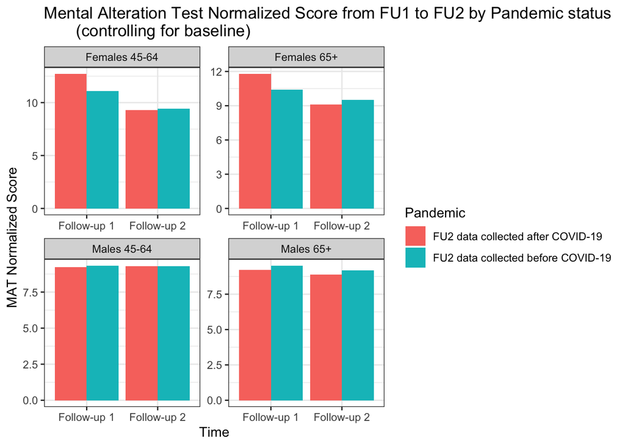

```r
MAT_lsmeans_adj11 <- summary(lsmeans(modelMAT_adj11, ~Pandemic|timefactor|Age_sex))
MAT_lsmeans_adj11$Time<-NA
MAT_lsmeans_adj11$Time[MAT_lsmeans_adj11$timefactor==1]<-"Follow-up 1"
MAT_lsmeans_adj11$Time[MAT_lsmeans_adj11$timefactor==2]<-"Follow-up 2"
ggplot(MAT_lsmeans_adj11, aes(x = Time, y = lsmean, fill = Pandemic)) +
  geom_bar(stat="identity", position=position_dodge()) + facet_wrap(~Age_sex, scales = "free") +
  labs(x = "Time", y = "MAT Normalized Score", title = "Mental Alteration Test Normalized Score from FU1 to FU2 by Pandemic status
       (controlling for baseline)") +
  theme_bw()
```

### 6.3.4) Post-hoc comparisons

```r
lsmeans.MAT <- lsmeans(modelMAT_adj11, ~Pandemic|timefactor|Age_sex)
contrast(lsmeans.MAT,list(c2nd, c3rd),by=NULL)
```

```
##  contrast
##  structure(c(0, 0, 0, 0, 0, 0, 0, 0, 0, 0, 0, 0, 1, -1, -1, 1), dim = c(16L,
##  structure(c(0, 0, 0, 0, 1, -1, -1, 1, 0, 0, 0, 0, 0, 0, 0, 0), dim = c(16L,
##    estimate        SE       df t.ratio p.value
##  -0.0151839 0.2070694 10043.53  -0.073  0.9415
##   1.7802465 0.2054848  9979.28   8.664  <.0001
##
## Results are averaged over the levels of: Education, Ethnicity, IncomeLevel, SmokingStatus, Relationshipstatus, Livingstatus, Anxiety, MoodDisord
## Degrees-of-freedom method: kenward-roger
```

```r
confint(contrast(lsmeans.MAT,list(c2nd, c3rd),by=NULL), parm, level = 0.95)
```

```
##  contrast
##  structure(c(0, 0, 0, 0, 0, 0, 0, 0, 0, 0, 0, 0, 1, -1, -1, 1), dim = c(16L,
##  structure(c(0, 0, 0, 0, 1, -1, -1, 1, 0, 0, 0, 0, 0, 0, 0, 0), dim = c(16L,
##    estimate        SE       df   lower.CL  upper.CL
##  -0.0151839 0.2070694 10043.53 -0.4210814 0.3907137
##   1.7802465 0.2054848  9979.28  1.3774549 2.1830381
##
## Results are averaged over the levels of: Education, Ethnicity, IncomeLevel, SmokingStatus, Relationshipstatus, Livingstatus, Anxiety, MoodDisord
## Degrees-of-freedom method: kenward-roger
## Confidence level used: 0.95
```

## 6.4) Animal Fluency

### 6.4.1) Model

```r
modelAnimals_adj11<- lmer(Animal_Fluency_Normed ~ timefactor*Pandemic*Age_sex + Education + Ethnicity + IncomeLevel + BMI + CESD.10baseline + SmokingStatus + Relationshipstatus +
                            Livingstatus + Anxiety + MoodDisord + Chronicconditions + Animal_Fluency_Normedbaseline +
                           (1|ID), data= Tracking.data_long_2)
summary(modelAnimals_adj11)
```

```
## Linear mixed model fit by REML. t-tests use Satterthwaite's method [
## lmerModLmerTest]
## Formula: Animal_Fluency_Normed ~ timefactor * Pandemic * Age_sex + Education +
##     Ethnicity + IncomeLevel + BMI + CESD.10baseline + SmokingStatus +
##     Relationshipstatus + Livingstatus + Anxiety + MoodDisord +
##     Chronicconditions + Animal_Fluency_Normedbaseline + (1 |      ID)
##    Data: Tracking.data_long_2
##
## REML criterion at convergence: 94883.1
##
## Scaled residuals:
##     Min      1Q  Median      3Q     Max
## -3.9084 -0.5456 -0.0177  0.5260  4.5905
##
## Random effects:
##  Groups   Name        Variance Std.Dev.
##  ID       (Intercept) 3.012    1.735
##  Residual             3.861    1.965
## Number of obs: 20333, groups:  ID, 10403
##
## Fixed effects:
##                                                                             Estimate
## (Intercept)                                                                4.188e+00
## timefactor2                                                                2.776e-01
## PandemicFU2 data collected before COVID-19                                 2.798e-01
## Age_sexFemales 65+                                                        -3.304e-01
## Age_sexMales 45-64                                                         6.509e-02
## Age_sexMales 65+                                                          -2.951e-01
## EducationHigh School Diploma                                               2.178e-01
## EducationLess than High School Diploma                                     5.810e-02
## EducationSome College                                                      2.113e-01
## EthnicityWhite                                                             5.876e-01
## IncomeLevel>$150k                                                          1.545e-01
## IncomeLevel$100-150k                                                       2.370e-01
## IncomeLevel$20-50k                                                        -1.204e-02
## IncomeLevel$50-100k                                                        1.912e-01
## BMI                                                                       -3.383e-03
## CESD.10baseline                                                           -1.300e-02
## SmokingStatusFormer Smoker                                                 7.776e-02
## SmokingStatusNever Smoked                                                  7.149e-02
```

[output cut: 214 more lines]

```
## MoodDisordYes
## Chronicconditions                                                         **
## Animal_Fluency_Normedbaseline                                             ***
## timefactor2:PandemicFU2 data collected before COVID-19
## timefactor2:Age_sexFemales 65+                                            **
## timefactor2:Age_sexMales 45-64                                            *
## timefactor2:Age_sexMales 65+                                              ***
## PandemicFU2 data collected before COVID-19:Age_sexFemales 65+
## PandemicFU2 data collected before COVID-19:Age_sexMales 45-64             *
## PandemicFU2 data collected before COVID-19:Age_sexMales 65+
## timefactor2:PandemicFU2 data collected before COVID-19:Age_sexFemales 65+
## timefactor2:PandemicFU2 data collected before COVID-19:Age_sexMales 45-64
## timefactor2:PandemicFU2 data collected before COVID-19:Age_sexMales 65+   *
## ---
## Signif. codes:  0 '***' 0.001 '**' 0.01 '*' 0.05 '.' 0.1 ' ' 1
```

```
##
## Correlation matrix not shown by default, as p = 40 > 12.
## Use print(x, correlation=TRUE)  or
##     vcov(x)        if you need it
```

```r
anova(modelAnimals_adj11)
```

```
## Type III Analysis of Variance Table with Satterthwaite's method
##                                Sum Sq Mean Sq NumDF DenDF   F value    Pr(>F)
## timefactor                        1.1     1.1     1 10161    0.2802  0.596560
## Pandemic                         68.2    68.2     1 10346   17.6669 2.654e-05
## Age_sex                         290.6    96.9     3 10344   25.0872 3.636e-16
## Education                        54.6    18.2     3 10347    4.7164  0.002721
## Ethnicity                        72.6    72.6     1 10290   18.8151 1.454e-05
## IncomeLevel                      70.0    17.5     4 10315    4.5353  0.001166
## BMI                               2.2     2.2     1 10274    0.5744  0.448517
## CESD.10baseline                  21.8    21.8     1 10351    5.6510  0.017464
## SmokingStatus                     5.0     1.7     3 10318    0.4349  0.727998
## Relationshipstatus               20.7     5.2     4 10346    1.3374  0.253362
## Livingstatus                     43.2    14.4     3 10265    3.7272  0.010811
## Anxiety                           1.6     1.6     1 10334    0.4145  0.519710
## MoodDisord                        7.3     7.3     1 10337    1.8862  0.169660
## Chronicconditions                27.6    27.6     1 10306    7.1372  0.007562
## Animal_Fluency_Normedbaseline 28580.1 28580.1     1 10308 7402.2611 < 2.2e-16
## timefactor:Pandemic               1.5     1.5     1 10161    0.3813  0.536933
## timefactor:Age_sex              107.6    35.9     3 10158    9.2928 3.921e-06
## Pandemic:Age_sex                 32.7    10.9     3 10346    2.8232  0.037292
## timefactor:Pandemic:Age_sex      21.1     7.0     3 10158    1.8212  0.140912
##
## timefactor
## Pandemic                      ***
## Age_sex                       ***
## Education                     **
## Ethnicity                     ***
## IncomeLevel                   **
## BMI
## CESD.10baseline               *
## SmokingStatus
## Relationshipstatus
## Livingstatus                  *
## Anxiety
## MoodDisord
## Chronicconditions             **
## Animal_Fluency_Normedbaseline ***
## timefactor:Pandemic
## timefactor:Age_sex            ***
## Pandemic:Age_sex              *
## timefactor:Pandemic:Age_sex
## ---
## Signif. codes:  0 '***' 0.001 '**' 0.01 '*' 0.05 '.' 0.1 ' ' 1
```

### 6.4.2) Estimated marginal means

Significantly lower animal fluency for males and females 65+

```r
lsmeans(modelAnimals_adj11, ~Pandemic|timefactor|Age_sex)
```

```
## timefactor = 1, Age_sex = Females 45-64:
##  Pandemic                             lsmean        SE       df lower.CL
##  FU2 data collected after COVID-19  10.94182 0.1571540 11565.78 10.63377
##  FU2 data collected before COVID-19 11.22163 0.1522728 11167.93 10.92315
##  upper.CL
##  11.24987
##  11.52011
##
## timefactor = 2, Age_sex = Females 45-64:
##  Pandemic                             lsmean        SE       df lower.CL
##  FU2 data collected after COVID-19  11.21946 0.1575160 11635.47 10.91070
##  FU2 data collected before COVID-19 11.38502 0.1522720 11167.75 11.08654
##  upper.CL
##  11.52822
##  11.68350
##
## timefactor = 1, Age_sex = Females 65+:
##  Pandemic                             lsmean        SE       df lower.CL
##  FU2 data collected after COVID-19  10.61142 0.1720851 12338.96 10.27410
##  FU2 data collected before COVID-19 10.95718 0.1625537 11691.72 10.63855
##  upper.CL
##  10.94873
##  11.27581
##
## timefactor = 2, Age_sex = Females 65+:
##  Pandemic                             lsmean        SE       df lower.CL
##  FU2 data collected after COVID-19  10.50797 0.1731142 12518.78 10.16864
##  FU2 data collected before COVID-19 10.78501 0.1627453 11727.44 10.46600
##  upper.CL
##  10.84730
##  11.10402
##
## timefactor = 1, Age_sex = Males 45-64:
##  Pandemic                             lsmean        SE       df lower.CL
##  FU2 data collected after COVID-19  11.00691 0.1510969 11256.97 10.71073
##  FU2 data collected before COVID-19 10.94938 0.1573710 11589.07 10.64091
##  upper.CL
##  11.30308
##  11.25785
##
```

[output cut: 12 more lines]

```
##  upper.CL
##  10.98433
##  11.11769
##
## timefactor = 2, Age_sex = Males 65+:
##  Pandemic                             lsmean        SE       df lower.CL
##  FU2 data collected after COVID-19  10.39719 0.1735233 12442.89 10.05706
##  FU2 data collected before COVID-19 10.79255 0.1625739 11796.59 10.47388
##  upper.CL
##  10.73733
##  11.11122
##
## Results are averaged over the levels of: Education, Ethnicity, IncomeLevel, SmokingStatus, Relationshipstatus, Livingstatus, Anxiety, MoodDisord
## Degrees-of-freedom method: kenward-roger
## Confidence level used: 0.95
```

```r
contrast(lsmeans(modelAnimals_adj11, ~Pandemic|timefactor|Age_sex), "pairwise", adj="none")
```

```
## timefactor = 1, Age_sex = Females 45-64:
##  contrast
##  (FU2 data collected after COVID-19) - (FU2 data collected before COVID-19)
##    estimate         SE       df t.ratio p.value
##  -0.2798116 0.09222059 17195.04  -3.034  0.0024
##
## timefactor = 2, Age_sex = Females 45-64:
##  contrast
##  (FU2 data collected after COVID-19) - (FU2 data collected before COVID-19)
##    estimate         SE       df t.ratio p.value
##  -0.1655659 0.09298700 17371.68  -1.781  0.0750
##
## timefactor = 1, Age_sex = Females 65+:
##  contrast
##  (FU2 data collected after COVID-19) - (FU2 data collected before COVID-19)
##    estimate         SE       df t.ratio p.value
##  -0.3457658 0.12610811 17113.21  -2.742  0.0061
##
## timefactor = 2, Age_sex = Females 65+:
##  contrast
##  (FU2 data collected after COVID-19) - (FU2 data collected before COVID-19)
##    estimate         SE       df t.ratio p.value
##  -0.2770368 0.12781135 17400.99  -2.168  0.0302
##
## timefactor = 1, Age_sex = Males 45-64:
##  contrast
##  (FU2 data collected after COVID-19) - (FU2 data collected before COVID-19)
##    estimate         SE       df t.ratio p.value
##   0.0575267 0.09418996 17216.69   0.611  0.5414
##
## timefactor = 2, Age_sex = Males 45-64:
##  contrast
##  (FU2 data collected after COVID-19) - (FU2 data collected before COVID-19)
##    estimate         SE       df t.ratio p.value
##  -0.0287995 0.09433809 17250.51  -0.305  0.7602
##
## timefactor = 1, Age_sex = Males 65+:
##  contrast
##  (FU2 data collected after COVID-19) - (FU2 data collected before COVID-19)
##    estimate         SE       df t.ratio p.value
##  -0.1523813 0.12513048 17174.64  -1.218  0.2233
##
## timefactor = 2, Age_sex = Males 65+:
##  contrast
##  (FU2 data collected after COVID-19) - (FU2 data collected before COVID-19)
##    estimate         SE       df t.ratio p.value
##  -0.3953577 0.12680302 17456.73  -3.118  0.0018
##
## Results are averaged over the levels of: Education, Ethnicity, IncomeLevel, SmokingStatus, Relationshipstatus, Livingstatus, Anxiety, MoodDisord
## Degrees-of-freedom method: kenward-roger
```

```r
confint(contrast(lsmeans(modelAnimals_adj11, ~Pandemic|timefactor|Age_sex), "pairwise", adj="none"), parm, level = 0.95)
```

```
## timefactor = 1, Age_sex = Females 45-64:
##  contrast
##  (FU2 data collected after COVID-19) - (FU2 data collected before COVID-19)
##    estimate         SE       df   lower.CL    upper.CL
##  -0.2798116 0.09222059 17195.04 -0.4605733 -0.09904982
##
## timefactor = 2, Age_sex = Females 45-64:
##  contrast
##  (FU2 data collected after COVID-19) - (FU2 data collected before COVID-19)
##    estimate         SE       df   lower.CL    upper.CL
##  -0.1655659 0.09298700 17371.68 -0.3478298  0.01669796
##
## timefactor = 1, Age_sex = Females 65+:
##  contrast
##  (FU2 data collected after COVID-19) - (FU2 data collected before COVID-19)
##    estimate         SE       df   lower.CL    upper.CL
##  -0.3457658 0.12610811 17113.21 -0.5929506 -0.09858097
##
## timefactor = 2, Age_sex = Females 65+:
##  contrast
##  (FU2 data collected after COVID-19) - (FU2 data collected before COVID-19)
##    estimate         SE       df   lower.CL    upper.CL
##  -0.2770368 0.12781135 17400.99 -0.5275599 -0.02651376
##
## timefactor = 1, Age_sex = Males 45-64:
##  contrast
##  (FU2 data collected after COVID-19) - (FU2 data collected before COVID-19)
##    estimate         SE       df   lower.CL    upper.CL
##   0.0575267 0.09418996 17216.69 -0.1270952  0.24214860
##
## timefactor = 2, Age_sex = Males 45-64:
##  contrast
##  (FU2 data collected after COVID-19) - (FU2 data collected before COVID-19)
##    estimate         SE       df   lower.CL    upper.CL
##  -0.0287995 0.09433809 17250.51 -0.2137118  0.15611272
##
## timefactor = 1, Age_sex = Males 65+:
##  contrast
##  (FU2 data collected after COVID-19) - (FU2 data collected before COVID-19)
##    estimate         SE       df   lower.CL    upper.CL
##  -0.1523813 0.12513048 17174.64 -0.3976499  0.09288719
##
## timefactor = 2, Age_sex = Males 65+:
##  contrast
##  (FU2 data collected after COVID-19) - (FU2 data collected before COVID-19)
##    estimate         SE       df   lower.CL    upper.CL
##  -0.3953577 0.12680302 17456.73 -0.6439043 -0.14681116
##
## Results are averaged over the levels of: Education, Ethnicity, IncomeLevel, SmokingStatus, Relationshipstatus, Livingstatus, Anxiety, MoodDisord
## Degrees-of-freedom method: kenward-roger
## Confidence level used: 0.95
```

### 6.4.3) Graph of estimated marginal means

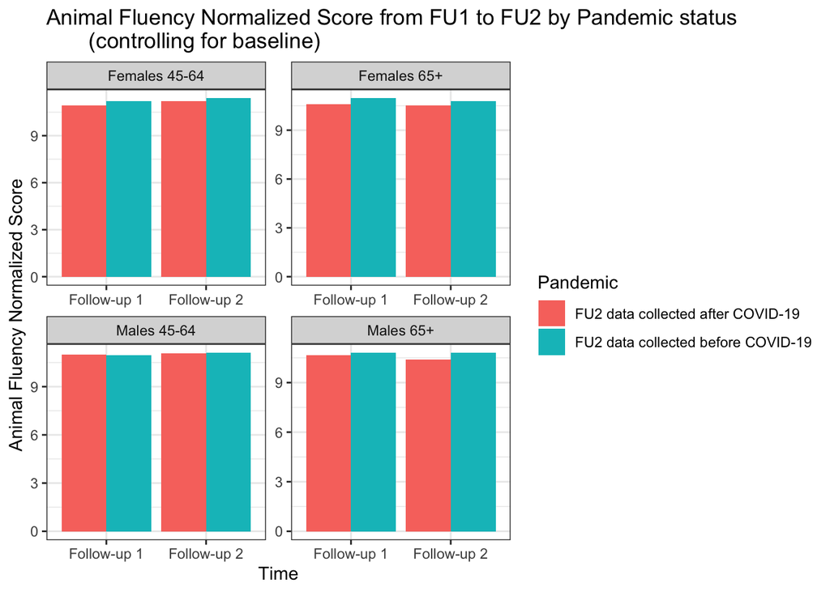

```r
Animals_lsmeans_adj11 <- summary(lsmeans(modelAnimals_adj11, ~timefactor|Pandemic|Age_sex))
Animals_lsmeans_adj11$Time<-NA
Animals_lsmeans_adj11$Time[Animals_lsmeans_adj11$timefactor==1]<-"Follow-up 1"
Animals_lsmeans_adj11$Time[Animals_lsmeans_adj11$timefactor==2]<-"Follow-up 2"
ggplot(Animals_lsmeans_adj11, aes(x = Time, y = lsmean, fill = Pandemic)) +
  geom_bar(stat="identity", position=position_dodge()) + facet_wrap(~Age_sex, scales = "free") +
  labs(x = "Time", y = "Animal Fluency Normalized Score", title = "Animal Fluency Normalized Score from FU1 to FU2 by Pandemic status
       (controlling for baseline)") +
  theme_bw()
```

### 6.4.4) Post-hoc comparisons

There was a significant difference between cohorts for males and females 65+. This post-hoc comparison determines if differences between cohorts at FU1 and FU2 for 65+ males and females are significant.

```r
lsmeans.animals <- lsmeans(modelAnimals_adj11, ~Pandemic|timefactor|Age_sex)
contrast(lsmeans.animals,list(c2nd, c3rd),by=NULL)
```

```
##  contrast
##  structure(c(0, 0, 0, 0, 0, 0, 0, 0, 0, 0, 0, 0, 1, -1, -1, 1), dim = c(16L,
##  structure(c(0, 0, 0, 0, 1, -1, -1, 1, 0, 0, 0, 0, 0, 0, 0, 0), dim = c(16L,
##     estimate        SE       df t.ratio p.value
##   0.24297640 0.1345418 10195.99   1.806  0.0710
##  -0.06872897 0.1350530 10187.46  -0.509  0.6108
##
## Results are averaged over the levels of: Education, Ethnicity, IncomeLevel, SmokingStatus, Relationshipstatus, Livingstatus, Anxiety, MoodDisord
## Degrees-of-freedom method: kenward-roger
```

```r
confint(contrast(lsmeans.animals,list(c2nd, c3rd),by=NULL), parm, level=0.95)
```

```
##  contrast
##  structure(c(0, 0, 0, 0, 0, 0, 0, 0, 0, 0, 0, 0, 1, -1, -1, 1), dim = c(16L,
##  structure(c(0, 0, 0, 0, 1, -1, -1, 1, 0, 0, 0, 0, 0, 0, 0, 0), dim = c(16L,
##     estimate        SE       df   lower.CL  upper.CL
##   0.24297640 0.1345418 10195.99 -0.0207520 0.5067048
##  -0.06872897 0.1350530 10187.46 -0.3334594 0.1960015
##
## Results are averaged over the levels of: Education, Ethnicity, IncomeLevel, SmokingStatus, Relationshipstatus, Livingstatus, Anxiety, MoodDisord
## Degrees-of-freedom method: kenward-roger
## Confidence level used: 0.95
```

# 7) Physical Activity Results

## 7.1) Main effects model adjusted for baseline

### 7.1.1) Model

```r
modelPASE_2<- lmer(PASE_TOTAL ~ timefactor*Pandemic + Age + Sex + Education + Ethnicity + IncomeLevel + BMI + CESD.10baseline + SmokingStatus +
                         Relationshipstatus + Livingstatus + Anxiety + MoodDisord + Chronicconditions + PASE_TOTALbaseline +
                        (1|ID), data= Tracking.data_long_2)
summary(modelPASE_2)
```

```
## Linear mixed model fit by REML. t-tests use Satterthwaite's method [
## lmerModLmerTest]
## Formula: PASE_TOTAL ~ timefactor * Pandemic + Age + Sex + Education +
##     Ethnicity + IncomeLevel + BMI + CESD.10baseline + SmokingStatus +
##     Relationshipstatus + Livingstatus + Anxiety + MoodDisord +
##     Chronicconditions + PASE_TOTALbaseline + (1 | ID)
##    Data: Tracking.data_long_2
##
## REML criterion at convergence: 41379.2
##
## Scaled residuals:
##     Min      1Q  Median      3Q     Max
## -2.6919 -0.5399 -0.0547  0.5147  4.6443
##
## Random effects:
##  Groups   Name        Variance Std.Dev.
##  ID       (Intercept) 1120     33.47
##  Residual             2268     47.62
## Number of obs: 3793, groups:  ID, 3084
##
## Fixed effects:
##                                                          Estimate Std. Error
## (Intercept)                                             227.04329   14.48019
## timefactor2                                             -19.57979    2.64778
## PandemicFU2 data collected before COVID-19               -8.30427    2.75447
## Age                                                      -2.28226    0.13554
## SexM                                                     19.08687    2.26456
## EducationHigh School Diploma                            -10.28018    3.35721
## EducationLess than High School Diploma                   -2.60637    5.33767
## EducationSome College                                     5.82881    3.88524
## EthnicityWhite                                           15.65811    6.50262
## IncomeLevel>$150k                                        10.13841    5.72612
## IncomeLevel$100-150k                                     13.35465    4.63478
## IncomeLevel$20-50k                                        6.55322    3.32002
## IncomeLevel$50-100k                                      10.32450    3.48386
## BMI                                                      -0.44277    0.23659
## CESD.10baseline                                           0.17110    0.26176
## SmokingStatusFormer Smoker                               -2.90890    4.82660
## SmokingStatusNever Smoked                                -0.02248    4.98545
## SmokingStatusOccasional Smoker                           -7.94910    8.41014
```

[output cut: 61 more lines]

```
## SmokingStatusOccasional Smoker                          0.34465
## RelationshipstatusMarried                               0.32198
## RelationshipstatusSeparated                             0.68339
## RelationshipstatusSingle                                0.21060
## RelationshipstatusWidowed                               0.88511
## LivingstatusAssisted Living                             0.33119
## LivingstatusHouse                                      9.99e-05 ***
## LivingstatusOther                                       0.01223 *
## AnxietyYes                                              0.62947
## MoodDisordYes                                           0.00196 **
## Chronicconditions                                       0.00206 **
## PASE_TOTALbaseline                                      < 2e-16 ***
## timefactor2:PandemicFU2 data collected before COVID-19 1.14e-05 ***
## ---
## Signif. codes:  0 '***' 0.001 '**' 0.01 '*' 0.05 '.' 0.1 ' ' 1
```

```
##
## Correlation matrix not shown by default, as p = 30 > 12.
## Use print(x, correlation=TRUE)  or
##     vcov(x)        if you need it
```

```r
anova(modelPASE_2)
```

```
## Type III Analysis of Variance Table with Satterthwaite's method
##                      Sum Sq Mean Sq NumDF  DenDF  F value    Pr(>F)
## timefactor           101726  101726     1 2197.8  44.8562 2.684e-11 ***
## Pandemic                159     159     1 2897.0   0.0701 0.7911985
## Age                  642968  642968     1 2936.6 283.5180 < 2.2e-16 ***
## Sex                  161106  161106     1 2908.6  71.0398 < 2.2e-16 ***
## Education             29766    9922     3 2936.2   4.3751 0.0044290 **
## Ethnicity             13150   13150     1 3166.3   5.7983 0.0160983 *
## IncomeLevel           25226    6307     4 2902.4   2.7809 0.0253960 *
## BMI                    7943    7943     1 2952.6   3.5023 0.0613809 .
## CESD.10baseline         969     969     1 2907.4   0.4272 0.5134007
## SmokingStatus          5932    1977     3 2853.5   0.8720 0.4548324
## Relationshipstatus     6543    1636     4 2848.8   0.7212 0.5773315
## Livingstatus          47512   15837     3 3005.3   6.9835 0.0001114 ***
## Anxiety                 528     528     1 2935.1   0.2328 0.6294745
## MoodDisord            21770   21770     1 2943.6   9.5995 0.0019647 **
## Chronicconditions     21573   21573     1 2856.9   9.5125 0.0020603 **
## PASE_TOTALbaseline  1343657 1343657     1 2899.1 592.4885 < 2.2e-16 ***
## timefactor:Pandemic   43880   43880     1 2199.0  19.3490 1.141e-05 ***
## ---
## Signif. codes:  0 '***' 0.001 '**' 0.01 '*' 0.05 '.' 0.1 ' ' 1
```

### 7.1.2) Estimated marginal means

```r
lsmeans(modelPASE_2, ~Pandemic|timefactor)
```

```
## timefactor = 1:
##  Pandemic                             lsmean       SE      df lower.CL upper.CL
##  FU2 data collected after COVID-19  159.7396 7.177553 3208.94 145.6665 173.8126
##  FU2 data collected before COVID-19 151.4353 7.142574 3214.64 137.4309 165.4398
##
## timefactor = 2:
##  Pandemic                             lsmean       SE      df lower.CL upper.CL
##  FU2 data collected after COVID-19  140.1598 7.146889 3191.36 126.1468 154.1728
##  FU2 data collected before COVID-19 147.3732 7.100724 3188.11 133.4507 161.2956
##
## Results are averaged over the levels of: Sex, Education, Ethnicity, IncomeLevel, SmokingStatus, Relationshipstatus, Livingstatus, Anxiety, MoodDisord
## Degrees-of-freedom method: kenward-roger
## Confidence level used: 0.95
```

```r
contrast(lsmeans(modelPASE_2, ~Pandemic|timefactor), "pairwise", adj="none")
```

```
## timefactor = 1:
##  contrast
##  (FU2 data collected after COVID-19) - (FU2 data collected before COVID-19)
##   estimate       SE      df t.ratio p.value
##   8.304269 2.755413 3751.52   3.014  0.0026
##
## timefactor = 2:
##  contrast
##  (FU2 data collected after COVID-19) - (FU2 data collected before COVID-19)
##   estimate       SE      df t.ratio p.value
##  -7.213373 2.669659 3761.29  -2.702  0.0069
##
## Results are averaged over the levels of: Sex, Education, Ethnicity, IncomeLevel, SmokingStatus, Relationshipstatus, Livingstatus, Anxiety, MoodDisord
## Degrees-of-freedom method: kenward-roger
```

```r
confint(contrast(lsmeans(modelPASE_2, ~Pandemic|timefactor), "pairwise", adj="none"), parm, level = 0.95)
```

```
## timefactor = 1:
##  contrast
##  (FU2 data collected after COVID-19) - (FU2 data collected before COVID-19)
##   estimate       SE      df   lower.CL  upper.CL
##   8.304269 2.755413 3751.52   2.902015 13.706523
##
## timefactor = 2:
##  contrast
##  (FU2 data collected after COVID-19) - (FU2 data collected before COVID-19)
##   estimate       SE      df   lower.CL  upper.CL
##  -7.213373 2.669659 3761.29 -12.447492 -1.979254
##
## Results are averaged over the levels of: Sex, Education, Ethnicity, IncomeLevel, SmokingStatus, Relationshipstatus, Livingstatus, Anxiety, MoodDisord
## Degrees-of-freedom method: kenward-roger
## Confidence level used: 0.95
```

### 7.1.3) Graph of estimated marginal means

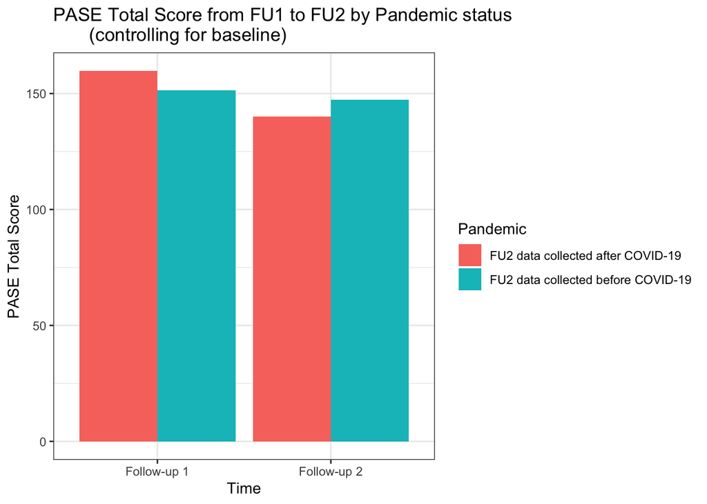

```r
PASE_lsmeans_2 <- summary(lsmeans(modelPASE_2, ~timefactor|Pandemic))
PASE_lsmeans_2$Time<-NA
PASE_lsmeans_2$Time[PASE_lsmeans_2$timefactor==1]<-"Follow-up 1"
PASE_lsmeans_2$Time[PASE_lsmeans_2$timefactor==2]<-"Follow-up 2"
ggplot(PASE_lsmeans_2, aes(x = Time, y = lsmean, fill = Pandemic)) +
  geom_bar(stat="identity", position=position_dodge()) +
  labs(x = "Time", y = "PASE Total Score", title = "PASE Total Score from FU1 to FU2 by Pandemic status
       (controlling for baseline)") +
  theme_bw()
```

### 7.1.4) Post-hoc comparisons

Test whether differences between cohorts at FU1 and FU2 are significant

```r
lsmeans.PASE <- lsmeans(modelPASE_2, ~Pandemic|timefactor)
contrast(lsmeans.PASE,list(c1st),by=NULL)
```

```
##  contrast                                     estimate       SE      df t.ratio
##  structure(c(-1, 1, 1, -1), dim = c(4L, 1L)) -15.51764 3.529829 2307.99  -4.396
##  p.value
##   <.0001
##
## Results are averaged over the levels of: Sex, Education, Ethnicity, IncomeLevel, SmokingStatus, Relationshipstatus, Livingstatus, Anxiety, MoodDisord
## Degrees-of-freedom method: kenward-roger
```

## 7.2) Age and Sex Interaction Model

### 7.2.1) Model

```r
modelPASE_4<- lmer(PASE_TOTAL ~ timefactor*Pandemic*Age_sex + Education + Ethnicity + IncomeLevel + BMI + CESD.10baseline + SmokingStatus +
                         Relationshipstatus + Livingstatus + Anxiety + MoodDisord + Chronicconditions + PASE_TOTALbaseline +
                        (1|ID), data= Tracking.data_long_2)
summary(modelPASE_4)
```

```
## Linear mixed model fit by REML. t-tests use Satterthwaite's method [
## lmerModLmerTest]
## Formula:
## PASE_TOTAL ~ timefactor * Pandemic * Age_sex + Education + Ethnicity +
##     IncomeLevel + BMI + CESD.10baseline + SmokingStatus + Relationshipstatus +
##     Livingstatus + Anxiety + MoodDisord + Chronicconditions +
##     PASE_TOTALbaseline + (1 | ID)
##    Data: Tracking.data_long_2
##
## REML criterion at convergence: 41443.6
##
## Scaled residuals:
##     Min      1Q  Median      3Q     Max
## -2.5900 -0.5394 -0.0518  0.4975  4.3962
##
## Random effects:
##  Groups   Name        Variance Std.Dev.
##  ID       (Intercept) 1281     35.79
##  Residual             2248     47.41
## Number of obs: 3793, groups:  ID, 3084
##
## Fixed effects:
##                                                                             Estimate
## (Intercept)                                                                 93.33664
## timefactor2                                                                -25.70659
## PandemicFU2 data collected before COVID-19                                 -13.80216
## Age_sexFemales 65+                                                         -35.79615
## Age_sexMales 45-64                                                          13.17052
## Age_sexMales 65+                                                           -17.99018
## EducationHigh School Diploma                                               -11.03172
## EducationLess than High School Diploma                                      -6.09233
## EducationSome College                                                        3.85447
## EthnicityWhite                                                              12.53759
## IncomeLevel>$150k                                                           11.95504
## IncomeLevel$100-150k                                                        15.37351
## IncomeLevel$20-50k                                                           5.44354
## IncomeLevel$50-100k                                                         10.93393
## BMI                                                                         -0.30116
## CESD.10baseline                                                              0.33349
## SmokingStatusFormer Smoker                                                  -4.52178
```

[output cut: 215 more lines]

```
## MoodDisordYes                                                             **
## Chronicconditions                                                         ***
## PASE_TOTALbaseline                                                        ***
## timefactor2:PandemicFU2 data collected before COVID-19                    ***
## timefactor2:Age_sexFemales 65+
## timefactor2:Age_sexMales 45-64                                            .
## timefactor2:Age_sexMales 65+
## PandemicFU2 data collected before COVID-19:Age_sexFemales 65+             .
## PandemicFU2 data collected before COVID-19:Age_sexMales 45-64
## PandemicFU2 data collected before COVID-19:Age_sexMales 65+
## timefactor2:PandemicFU2 data collected before COVID-19:Age_sexFemales 65+
## timefactor2:PandemicFU2 data collected before COVID-19:Age_sexMales 45-64 .
## timefactor2:PandemicFU2 data collected before COVID-19:Age_sexMales 65+
## ---
## Signif. codes:  0 '***' 0.001 '**' 0.01 '*' 0.05 '.' 0.1 ' ' 1
```

```
##
## Correlation matrix not shown by default, as p = 40 > 12.
## Use print(x, correlation=TRUE)  or
##     vcov(x)        if you need it
```

```r
anova(modelPASE_4)
```

```
## Type III Analysis of Variance Table with Satterthwaite's method
##                              Sum Sq Mean Sq NumDF  DenDF  F value    Pr(>F)
## timefactor                    85569   85569     1 2203.4  38.0727 8.087e-10 ***
## Pandemic                         54      54     1 2942.6   0.0242  0.876390
## Age_sex                      358861  119620     3 2941.1  53.2237 < 2.2e-16 ***
## Education                     29146    9715     3 2953.8   4.3227  0.004764 **
## Ethnicity                      7989    7989     1 3160.3   3.5545  0.059475 .
## IncomeLevel                   33205    8301     4 2921.4   3.6935  0.005268 **
## BMI                            3476    3476     1 2968.3   1.5466  0.213732
## CESD.10baseline                3476    3476     1 2925.6   1.5466  0.213739
## SmokingStatus                  6921    2307     3 2875.8   1.0264  0.379731
## Relationshipstatus            10753    2688     4 2870.1   1.1961  0.310384
## Livingstatus                  61960   20653     3 3018.5   9.1895 4.742e-06 ***
## Anxiety                           3       3     1 2951.8   0.0015  0.968881
## MoodDisord                    16546   16546     1 2962.5   7.3618  0.006701 **
## Chronicconditions             48160   48160     1 2881.4  21.4284 3.835e-06 ***
## PASE_TOTALbaseline          1809574 1809574     1 2928.3 805.1474 < 2.2e-16 ***
## timefactor:Pandemic           45087   45087     1 2205.2  20.0609 7.884e-06 ***
## timefactor:Age_sex             3129    1043     3 2186.6   0.4640  0.707413
## Pandemic:Age_sex               6950    2317     3 2928.8   1.0308  0.377750
## timefactor:Pandemic:Age_sex   23076    7692     3 2189.6   3.4225  0.016587 *
## ---
## Signif. codes:  0 '***' 0.001 '**' 0.01 '*' 0.05 '.' 0.1 ' ' 1
```

### 7.2.2) Estimated marginal means

```r
lsmeans(modelPASE_4, ~Pandemic|timefactor|Age_sex)
```

```
## timefactor = 1, Age_sex = Females 45-64:
##  Pandemic                             lsmean       SE      df  lower.CL
##  FU2 data collected after COVID-19  164.3075 7.931349 3323.35 148.75665
##  FU2 data collected before COVID-19 150.5053 7.704861 3324.44 135.39855
##  upper.CL
##  179.8583
##  165.6121
##
## timefactor = 2, Age_sex = Females 45-64:
##  Pandemic                             lsmean       SE      df  lower.CL
##  FU2 data collected after COVID-19  138.6009 7.955978 3336.64 123.00179
##  FU2 data collected before COVID-19 145.9738 7.569606 3248.00 131.13211
##  upper.CL
##  154.2000
##  160.8155
##
## timefactor = 1, Age_sex = Females 65+:
##  Pandemic                             lsmean       SE      df  lower.CL
##  FU2 data collected after COVID-19  128.5113 9.114301 3519.14 110.64147
##  FU2 data collected before COVID-19 129.0447 8.441697 3465.46 112.49353
##  upper.CL
##  146.3812
##  145.5959
##
## timefactor = 2, Age_sex = Females 65+:
##  Pandemic                             lsmean       SE      df  lower.CL
##  FU2 data collected after COVID-19  115.6964 9.128252 3519.48  97.79919
##  FU2 data collected before COVID-19 123.4574 8.169905 3347.79 107.43892
##  upper.CL
##  133.5936
##  139.4759
##
## timefactor = 1, Age_sex = Males 45-64:
##  Pandemic                             lsmean       SE      df  lower.CL
##  FU2 data collected after COVID-19  177.4780 7.790232 3310.17 162.20383
##  FU2 data collected before COVID-19 169.9205 8.094849 3397.42 154.04923
##  upper.CL
##  192.7522
##  185.7918
##
```

[output cut: 12 more lines]

```
##  upper.CL
##  163.4678
##  147.2437
##
## timefactor = 2, Age_sex = Males 65+:
##  Pandemic                             lsmean       SE      df  lower.CL
##  FU2 data collected after COVID-19  115.2892 9.127439 3543.08  97.39362
##  FU2 data collected before COVID-19 136.7721 8.226797 3362.42 120.64206
##  upper.CL
##  133.1848
##  152.9021
##
## Results are averaged over the levels of: Education, Ethnicity, IncomeLevel, SmokingStatus, Relationshipstatus, Livingstatus, Anxiety, MoodDisord
## Degrees-of-freedom method: kenward-roger
## Confidence level used: 0.95
```

```r
contrast(lsmeans(modelPASE_4, ~Pandemic|timefactor|Age_sex), "pairwise", adj="none")
```

```
## timefactor = 1, Age_sex = Females 45-64:
##  contrast
##  (FU2 data collected after COVID-19) - (FU2 data collected before COVID-19)
##    estimate       SE      df t.ratio p.value
##   13.802165 4.663612 3725.15   2.960  0.0031
##
## timefactor = 2, Age_sex = Females 45-64:
##  contrast
##  (FU2 data collected after COVID-19) - (FU2 data collected before COVID-19)
##    estimate       SE      df t.ratio p.value
##   -7.372923 4.452537 3748.32  -1.656  0.0978
##
## timefactor = 1, Age_sex = Females 65+:
##  contrast
##  (FU2 data collected after COVID-19) - (FU2 data collected before COVID-19)
##    estimate       SE      df t.ratio p.value
##   -0.533419 7.072622 3744.51  -0.075  0.9399
##
## timefactor = 2, Age_sex = Females 65+:
##  contrast
##  (FU2 data collected after COVID-19) - (FU2 data collected before COVID-19)
##    estimate       SE      df t.ratio p.value
##   -7.761034 7.183009 3739.30  -1.080  0.2800
##
## timefactor = 1, Age_sex = Males 45-64:
##  contrast
##  (FU2 data collected after COVID-19) - (FU2 data collected before COVID-19)
##    estimate       SE      df t.ratio p.value
##    7.557493 5.101771 3728.70   1.481  0.1386
##
## timefactor = 2, Age_sex = Males 45-64:
##  contrast
##  (FU2 data collected after COVID-19) - (FU2 data collected before COVID-19)
##    estimate       SE      df t.ratio p.value
##    3.016380 4.798867 3751.39   0.629  0.5297
##
## timefactor = 1, Age_sex = Males 65+:
##  contrast
##  (FU2 data collected after COVID-19) - (FU2 data collected before COVID-19)
##    estimate       SE      df t.ratio p.value
##   15.597954 6.727868 3748.14   2.318  0.0205
##
## timefactor = 2, Age_sex = Males 65+:
##  contrast
##  (FU2 data collected after COVID-19) - (FU2 data collected before COVID-19)
##    estimate       SE      df t.ratio p.value
##  -21.482911 6.936701 3739.82  -3.097  0.0020
##
## Results are averaged over the levels of: Education, Ethnicity, IncomeLevel, SmokingStatus, Relationshipstatus, Livingstatus, Anxiety, MoodDisord
## Degrees-of-freedom method: kenward-roger
```

```r
confint(contrast(lsmeans(modelPASE_4, ~Pandemic|timefactor|Age_sex), "pairwise", adj="none"), parm, level = 0.95)
```

```
## timefactor = 1, Age_sex = Females 45-64:
##  contrast
##  (FU2 data collected after COVID-19) - (FU2 data collected before COVID-19)
##    estimate       SE      df  lower.CL  upper.CL
##   13.802165 4.663612 3725.15   4.65868 22.945647
##
## timefactor = 2, Age_sex = Females 45-64:
##  contrast
##  (FU2 data collected after COVID-19) - (FU2 data collected before COVID-19)
##    estimate       SE      df  lower.CL  upper.CL
##   -7.372923 4.452537 3748.32 -16.10255  1.356708
##
## timefactor = 1, Age_sex = Females 65+:
##  contrast
##  (FU2 data collected after COVID-19) - (FU2 data collected before COVID-19)
##    estimate       SE      df  lower.CL  upper.CL
##   -0.533419 7.072622 3744.51 -14.39999 13.333148
##
## timefactor = 2, Age_sex = Females 65+:
##  contrast
##  (FU2 data collected after COVID-19) - (FU2 data collected before COVID-19)
##    estimate       SE      df  lower.CL  upper.CL
##   -7.761034 7.183009 3739.30 -21.84403  6.321963
##
## timefactor = 1, Age_sex = Males 45-64:
##  contrast
##  (FU2 data collected after COVID-19) - (FU2 data collected before COVID-19)
##    estimate       SE      df  lower.CL  upper.CL
##    7.557493 5.101771 3728.70  -2.44504 17.560027
##
## timefactor = 2, Age_sex = Males 45-64:
##  contrast
##  (FU2 data collected after COVID-19) - (FU2 data collected before COVID-19)
##    estimate       SE      df  lower.CL  upper.CL
##    3.016380 4.798867 3751.39  -6.39226 12.425022
##
## timefactor = 1, Age_sex = Males 65+:
##  contrast
##  (FU2 data collected after COVID-19) - (FU2 data collected before COVID-19)
##    estimate       SE      df  lower.CL  upper.CL
##   15.597954 6.727868 3748.14   2.40732 28.788594
##
## timefactor = 2, Age_sex = Males 65+:
##  contrast
##  (FU2 data collected after COVID-19) - (FU2 data collected before COVID-19)
##    estimate       SE      df  lower.CL  upper.CL
##  -21.482911 6.936701 3739.82 -35.08300 -7.882825
##
## Results are averaged over the levels of: Education, Ethnicity, IncomeLevel, SmokingStatus, Relationshipstatus, Livingstatus, Anxiety, MoodDisord
## Degrees-of-freedom method: kenward-roger
## Confidence level used: 0.95
```

### 7.2.3) Graph of estimated marginal means

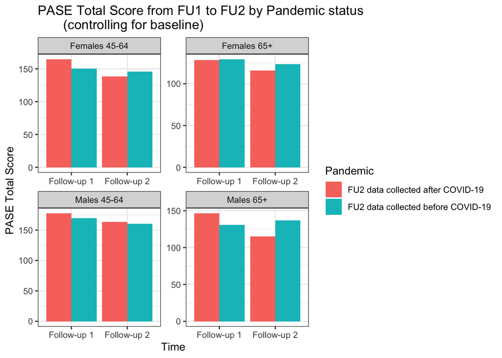

```r
PASE_lsmeans_4 <- summary(lsmeans(modelPASE_4, ~timefactor|Pandemic|Age_sex))
PASE_lsmeans_4$Time<-NA
PASE_lsmeans_4$Time[PASE_lsmeans_4$timefactor==1]<-"Follow-up 1"
PASE_lsmeans_4$Time[PASE_lsmeans_4$timefactor==2]<-"Follow-up 2"
ggplot(PASE_lsmeans_4, aes(x = Time, y = lsmean, fill = Pandemic)) +
  geom_bar(stat="identity", position=position_dodge()) + facet_wrap(~Age_sex, scales = "free") +
  labs(x = "Time", y = "PASE Total Score", title = "PASE Total Score from FU1 to FU2 by Pandemic status
       (controlling for baseline)") +
  theme_bw()
```

### 7.2.4) Post-hoc

```r
lsmeans.PASE1 <- lsmeans(modelPASE_4, ~Pandemic|timefactor|Age_sex)
contrast(lsmeans.PASE1,list(c2nd,c3rd,c4th),by=NULL)
```

```
##  contrast
##  structure(c(0, 0, 0, 0, 0, 0, 0, 0, 0, 0, 0, 0, 1, -1, -1, 1), dim = c(16L,
##  structure(c(0, 0, 0, 0, 1, -1, -1, 1, 0, 0, 0, 0, 0, 0, 0, 0), dim = c(16L,
##  structure(c(1, -1, -1, 1, 0, 0, 0, 0, 0, 0, 0, 0, 0, 0, 0, 0), dim = c(16L,
##  estimate       SE      df t.ratio p.value
##  37.08087 9.016611 2481.63   4.113  <.0001
##   7.22762 9.277665 2222.13   0.779  0.4360
##  21.17509 5.903682 2081.28   3.587  0.0003
##
## Results are averaged over the levels of: Education, Ethnicity, IncomeLevel, SmokingStatus, Relationshipstatus, Livingstatus, Anxiety, MoodDisord
## Degrees-of-freedom method: kenward-roger
```

```r
confint(contrast(lsmeans.PASE1,list(c2nd,c3rd,c4th),by=NULL), parm, level=0.95)
```

```
##  contrast
##  structure(c(0, 0, 0, 0, 0, 0, 0, 0, 0, 0, 0, 0, 1, -1, -1, 1), dim = c(16L,
##  structure(c(0, 0, 0, 0, 1, -1, -1, 1, 0, 0, 0, 0, 0, 0, 0, 0), dim = c(16L,
##  structure(c(1, -1, -1, 1, 0, 0, 0, 0, 0, 0, 0, 0, 0, 0, 0, 0), dim = c(16L,
##  estimate       SE      df   lower.CL upper.CL
##  37.08087 9.016611 2481.63  19.400010 54.76172
##   7.22762 9.277665 2222.13 -10.966184 25.42141
##  21.17509 5.903682 2081.28   9.597352 32.75282
##
## Results are averaged over the levels of: Education, Ethnicity, IncomeLevel, SmokingStatus, Relationshipstatus, Livingstatus, Anxiety, MoodDisord
## Degrees-of-freedom method: kenward-roger
## Confidence level used: 0.95
```

# 8) Sedentary behaviour Results

## 8.1) Full model adjusted for baseline

Create binary variable for 4+ hrs/day of SB

```r
Tracking.data_long_2$SB.binary <- as.factor(ifelse(Tracking.data_long_2$PASE_Sit==10, 1, 0))
Tracking.data_long_2$SBbaseline.binary <- as.factor(ifelse(Tracking.data_long_2$PASE_Sitbaseline==10, 1, 0))
```

### 8.1.1) Model

```r
sit1 <- glmer(
  SB.binary ~ timefactor*Pandemic + Age + Sex + SBbaseline.binary + Education + Ethnicity + IncomeLevel + BMI + CESD.10baseline + SmokingStatus +
    Relationshipstatus + Livingstatus + Anxiety + MoodDisord + Chronicconditions +
    (1|ID),
  data = Tracking.data_long_2,
  family = binomial(link = "logit")
)
summary(sit1)
```

```
## Generalized linear mixed model fit by maximum likelihood (Laplace
##   Approximation) [glmerMod]
##  Family: binomial  ( logit )
## Formula: SB.binary ~ timefactor * Pandemic + Age + Sex + SBbaseline.binary +
##     Education + Ethnicity + IncomeLevel + BMI + CESD.10baseline +
##     SmokingStatus + Relationshipstatus + Livingstatus + Anxiety +
##     MoodDisord + Chronicconditions + (1 | ID)
##    Data: Tracking.data_long_2
##
##      AIC      BIC   logLik deviance df.resid
##  25490.9  25736.5 -12714.5  25428.9    20362
##
## Scaled residuals:
##     Min      1Q  Median      3Q     Max
## -2.9792 -0.6519 -0.4604  0.7979  2.0551
##
## Random effects:
##  Groups Name        Variance Std.Dev.
##  ID     (Intercept) 0.8009   0.8949
## Number of obs: 20393, groups:  ID, 10230
##
## Fixed effects:
##                                                         Estimate Std. Error
## (Intercept)                                            -2.345677   0.236629
## timefactor2                                             0.484549   0.048672
## PandemicFU2 data collected before COVID-19              0.077020   0.050532
## Age                                                     0.015468   0.002267
## SexM                                                   -0.132471   0.041411
## SBbaseline.binary1                                      1.144900   0.040837
## EducationHigh School Diploma                           -0.013064   0.058193
## EducationLess than High School Diploma                  0.088360   0.079516
## EducationSome College                                  -0.088507   0.072900
## EthnicityWhite                                         -0.132508   0.114038
## IncomeLevel>$150k                                      -0.192826   0.110874
## IncomeLevel$100-150k                                   -0.002932   0.086971
## IncomeLevel$20-50k                                     -0.145662   0.056702
## IncomeLevel$50-100k                                    -0.221989   0.061614
## BMI                                                     0.039903   0.003849
## CESD.10baseline                                         0.012534   0.004626
## SmokingStatusFormer Smoker                             -0.297567   0.077320
```

[output cut: 31 more lines]

```
## SmokingStatusNever Smoked                               -3.931 8.47e-05 ***
## SmokingStatusOccasional Smoker                          -2.206 0.027396 *
## RelationshipstatusMarried                               -2.623 0.008717 **
## RelationshipstatusSeparated                              0.510 0.610165
## RelationshipstatusSingle                                 0.858 0.390763
## RelationshipstatusWidowed                                0.117 0.907046
## LivingstatusAssisted Living                              1.034 0.301280
## LivingstatusHouse                                       -3.916 9.01e-05 ***
## LivingstatusOther                                       -2.170 0.030004 *
## AnxietyYes                                              -0.260 0.795137
## MoodDisordYes                                            1.815 0.069474 .
## Chronicconditions                                        4.009 6.09e-05 ***
## timefactor2:PandemicFU2 data collected before COVID-19  -6.705 2.02e-11 ***
## ---
## Signif. codes:  0 '***' 0.001 '**' 0.01 '*' 0.05 '.' 0.1 ' ' 1
```

```
##
## Correlation matrix not shown by default, as p = 30 > 12.
## Use print(x, correlation=TRUE)  or
##     vcov(x)        if you need it
```

```
## optimizer (Nelder_Mead) convergence code: 4 (failure to converge in 10000 evaluations)
## Model failed to converge with max|grad| = 2.09548 (tol = 0.002, component 1)
## Model is nearly unidentifiable: very large eigenvalue
##  - Rescale variables?
## failure to converge in 10000 evaluations
```

```r
anova(sit1)
```

```
## Analysis of Variance Table
##                     npar  Sum Sq Mean Sq   F value
## timefactor             1   43.77   43.77   43.7704
## Pandemic               1    0.95    0.95    0.9505
## Age                    1  157.28  157.28  157.2766
## Sex                    1   33.93   33.93   33.9339
## SBbaseline.binary      1 1102.79 1102.79 1102.7864
## Education              3   12.04    4.01    4.0133
## Ethnicity              1    1.36    1.36    1.3621
## IncomeLevel            4   26.32    6.58    6.5811
## BMI                    1  147.30  147.30  147.3015
## CESD.10baseline        1   26.31   26.31   26.3056
## SmokingStatus          3   24.45    8.15    8.1507
## Relationshipstatus     4   39.99   10.00    9.9980
## Livingstatus           3   22.73    7.58    7.5754
## Anxiety                1    0.29    0.29    0.2939
## MoodDisord             1    5.03    5.03    5.0274
## Chronicconditions      1   17.26   17.26   17.2575
## timefactor:Pandemic    1   49.65   49.65   49.6523
```

### 8.1.2) Predicted probabilities

```r
ggpredict(sit1, c("timefactor", "Pandemic"))
```

```
## # Predicted probabilities of SB.binary
##
## Pandemic: FU2 data collected after COVID-19
##
## timefactor | Predicted |     95% CI
## -----------------------------------
## 1          |      0.46 | 0.39, 0.54
## 2          |      0.58 | 0.51, 0.65
##
## Pandemic: FU2 data collected before COVID-19
##
## timefactor | Predicted |     95% CI
## -----------------------------------
## 1          |      0.48 | 0.41, 0.56
## 2          |      0.49 | 0.42, 0.57
##
## Adjusted for:
## *                Age =                    60.00
## *                Sex =                        F
## *  SBbaseline.binary =                        0
## *          Education = College Degree or Higher
## *          Ethnicity =                    Other
## *        IncomeLevel =                    <$20k
## *                BMI =                    27.52
## *    CESD.10baseline =                     4.87
## *      SmokingStatus =             Daily Smoker
## * Relationshipstatus =                 Divorced
## *       Livingstatus = Apartment/Condo/Townhome
## *            Anxiety =                       No
## *         MoodDisord =                       No
## *  Chronicconditions =                     2.76
## *                 ID =     0 (population-level)
```

### 8.1.3) Estimated Mean Differences Between Pre- and Post-pandemic Cohorts at FU1 and FU2

Calculating estimated mean differences between cohorts

```r
#Create data frame
sit.test <- as.data.frame(ggpredict(sit1, c("timefactor", "Pandemic")))

#Determine standard errors
sit.test$standard.error <- (sit.test$predicted - sit.test$conf.low)/1.96

#Calculating estimated mean differences between cohorts at FU1
mean.diff.1<-(subset(sit.test,x==1 & group == "FU2 data collected after COVID-19")$predicted -
         subset(sit.test,x==1 & group == "FU2 data collected before COVID-19")$predicted)

se.1<-(sqrt(((subset(sit.test,x==1 & group == "FU2 data collected after COVID-19")$standard.error)^2 +
         (subset(sit.test,x==1 & group == "FU2 data collected before COVID-19")$standard.error^2))/2))

UL.1<-mean.diff.1 + se.1*1.96
LL.1<-mean.diff.1 - se.1*1.96


#Calculating estimated mean differences between cohorts at FU2
mean.diff.2<-(subset(sit.test,x==2 & group == "FU2 data collected after COVID-19")$predicted -
         subset(sit.test,x==2 & group == "FU2 data collected before COVID-19")$predicted)

se.2<-(sqrt(((subset(sit.test,x==2 & group == "FU2 data collected after COVID-19")$standard.error)^2 +
         (subset(sit.test,x==2 & group == "FU2 data collected before COVID-19")$standard.error^2))/2))

UL.2<-mean.diff.2 + se.2*1.96
LL.2<-mean.diff.2 - se.2*1.96


#Calculating z-scores for differences
z.1<- (subset(sit.test,x==1 & group == "FU2 data collected after COVID-19")$predicted -
         subset(sit.test,x==1 & group == "FU2 data collected before COVID-19")$predicted) / (sqrt(((subset(sit.test,x==1 & group == "FU2 data collected after COVID-19")$standard.error)^2 +
     (subset(sit.test,x==1 & group == "FU2 data collected before COVID-19")$standard.error^2))/2))

z.2<- (subset(sit.test,x==2 & group == "FU2 data collected after COVID-19")$predicted -
         subset(sit.test,x==2 & group == "FU2 data collected before COVID-19")$predicted) / (sqrt(((subset(sit.test,x==2 & group == "FU2 data collected after COVID-19")$standard.error)^2 +
         (subset(sit.test,x==2 & group == "FU2 data collected before COVID-19")$standard.error^2))/2))


#p-values for z-scores
p.1<-2*pnorm(z.1, mean = 0, sd = 1, lower.tail = TRUE)
p.2<-2*pnorm(z.2, mean = 0, sd = 1, lower.tail = FALSE)
```

Estimated mean differences between cohorts at FU1

```r
mean.diff.1 #mean difference
```

```
## [1] -0.01918833
```

```r
LL.1 #Lower 95% CI
```

```
## [1] -0.0931202
```

```r
UL.1 #Upper 95% CI
```

```
## [1] 0.05474353
```

```r
z.1 # z-score
```

```
## [1] -0.5086999
```

```r
p.1 #p-value
```

```
## [1] 0.6109626
```

Estimated mean differences between cohorts at FU2

```r
mean.diff.2 #mean difference
```

```
## [1] 0.08964482
```

```r
LL.2 #Lower 95% CI
```

```
## [1] 0.01499254
```

```r
UL.2 #Upper 95% CI
```

```
## [1] 0.1642971
```

```r
z.2 # z-score
```

```
## [1] 2.35363
```

```r
p.2 #p-value
```

```
## [1] 0.0185911
```

### 8.1.4) Graph of predicted probabilities

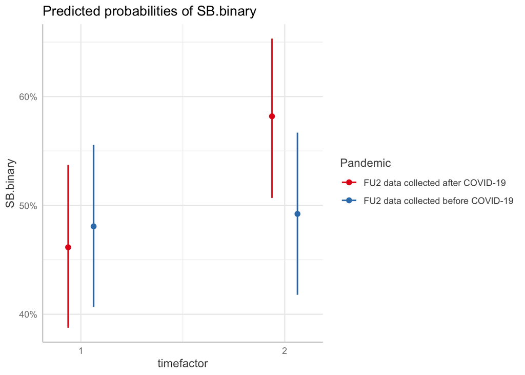

```r
ggpredict(sit1, c("timefactor", "Pandemic")) %>% plot()
```

### 8.1.5) Post-hoc analysis

Calculating between-cohort changes from FU1 to FU2

```r
#mean difference
mean.diff.1a<-((subset(sit.test,x==1 & group == "FU2 data collected after COVID-19")$predicted -
         subset(sit.test,x==2 & group == "FU2 data collected after COVID-19")$predicted))

mean.diff.1b<-((subset(sit.test,x==1 & group == "FU2 data collected before COVID-19")$predicted -
         subset(sit.test,x==2 & group == "FU2 data collected before COVID-19")$predicted))

mean.change<- mean.diff.1a - mean.diff.1b

#standard error
se.change<-(sqrt(((subset(sit.test,x==2 & group == "FU2 data collected after COVID-19")$standard.error)^2 +
         (subset(sit.test,x==2 & group == "FU2 data collected after COVID-19")$standard.error^2 +
            (subset(sit.test,x==2 & group == "FU2 data collected before COVID-19")$standard.error)^2 +
            (subset(sit.test,x==2 & group == "FU2 data collected before COVID-19")$standard.error)^2 ))/4))

#confidence interval
UL.change<-mean.change + se.change*1.96
LL.change<-mean.change - se.change*1.96

#t-score
t.change<-mean.change/se.change

#degrees of freedom
df <- length(Tracking.data_long_2$SB.binary)/2 - 2

#p-value
p.change <- pt(t.change, df)
```

Estimated between-cohort changes from FU1 to FU2

```r
mean.change #Between-cohort changes from FU1 to FU2
```

```
## [1] -0.1088332
```

```r
LL.change #LL 95% CI
```

```
## [1] -0.1834854
```

```r
UL.change #UL 95% CI
```

```
## [1] -0.03418088
```

```r
p.change #p-value
```

```
## [1] 0.002139377
```

## 8.2) Age and Sex Interaction Model

### 8.2.1) Model

```r
sit2 <- glmer(
  SB.binary ~ timefactor*Pandemic*Age_sex + SBbaseline.binary + Education + Ethnicity + IncomeLevel + BMI + CESD.10baseline + SmokingStatus +
    Relationshipstatus + Livingstatus + Anxiety + MoodDisord + Chronicconditions +
    (1|ID),
  data = Tracking.data_long_2,
  family = binomial(link = "logit")
)
summary(sit2)
```

```
## Generalized linear mixed model fit by maximum likelihood (Laplace
##   Approximation) [glmerMod]
##  Family: binomial  ( logit )
## Formula: SB.binary ~ timefactor * Pandemic * Age_sex + SBbaseline.binary +
##     Education + Ethnicity + IncomeLevel + BMI + CESD.10baseline +
##     SmokingStatus + Relationshipstatus + Livingstatus + Anxiety +
##     MoodDisord + Chronicconditions + (1 | ID)
##    Data: Tracking.data_long_2
##
##      AIC      BIC   logLik deviance df.resid
##  25497.3  25822.1 -12707.6  25415.3    20352
##
## Scaled residuals:
##     Min      1Q  Median      3Q     Max
## -2.9824 -0.6494 -0.4575  0.7973  2.0627
##
## Random effects:
##  Groups Name        Variance Std.Dev.
##  ID     (Intercept) 0.8119   0.9011
## Number of obs: 20393, groups:  ID, 10230
##
## Fixed effects:
##                                                                            Estimate
## (Intercept)                                                               -1.621409
## timefactor2                                                                0.580655
## PandemicFU2 data collected before COVID-19                                 0.057323
## Age_sexFemales 65+                                                         0.398905
## Age_sexMales 45-64                                                        -0.145723
## Age_sexMales 65+                                                           0.303746
## SBbaseline.binary1                                                         1.150987
## EducationHigh School Diploma                                              -0.004946
## EducationLess than High School Diploma                                     0.096593
## EducationSome College                                                     -0.073042
## EthnicityWhite                                                            -0.053967
## IncomeLevel>$150k                                                         -0.206616
## IncomeLevel$100-150k                                                      -0.032749
## IncomeLevel$20-50k                                                        -0.163106
## IncomeLevel$50-100k                                                       -0.243572
## BMI                                                                        0.039140
## CESD.10baseline                                                            0.011756
```

[output cut: 174 more lines]

```
## AnxietyYes
## MoodDisordYes                                                             .
## Chronicconditions                                                         ***
## timefactor2:PandemicFU2 data collected before COVID-19                    **
## timefactor2:Age_sexFemales 65+
## timefactor2:Age_sexMales 45-64
## timefactor2:Age_sexMales 65+
## PandemicFU2 data collected before COVID-19:Age_sexFemales 65+
## PandemicFU2 data collected before COVID-19:Age_sexMales 45-64
## PandemicFU2 data collected before COVID-19:Age_sexMales 65+
## timefactor2:PandemicFU2 data collected before COVID-19:Age_sexFemales 65+
## timefactor2:PandemicFU2 data collected before COVID-19:Age_sexMales 45-64
## timefactor2:PandemicFU2 data collected before COVID-19:Age_sexMales 65+   *
## ---
## Signif. codes:  0 '***' 0.001 '**' 0.01 '*' 0.05 '.' 0.1 ' ' 1
```

```
##
## Correlation matrix not shown by default, as p = 40 > 12.
## Use print(x, correlation=TRUE)  or
##     vcov(x)        if you need it
```

```
## optimizer (Nelder_Mead) convergence code: 4 (failure to converge in 10000 evaluations)
## Model failed to converge with max|grad| = 1.20199 (tol = 0.002, component 1)
## Model is nearly unidentifiable: very large eigenvalue
##  - Rescale variables?
## failure to converge in 10000 evaluations
```

```r
anova(sit2)
```

```
## Analysis of Variance Table
##                             npar  Sum Sq Mean Sq   F value
## timefactor                     1   47.09   47.09   47.0859
## Pandemic                       1    0.63    0.63    0.6299
## Age_sex                        3  165.71   55.24   55.2352
## SBbaseline.binary              1 1111.64 1111.64 1111.6354
## Education                      3   15.42    5.14    5.1387
## Ethnicity                      1    0.14    0.14    0.1418
## IncomeLevel                    4   29.48    7.37    7.3703
## BMI                            1  142.42  142.42  142.4247
## CESD.10baseline                1   24.35   24.35   24.3507
## SmokingStatus                  3   22.63    7.54    7.5440
## Relationshipstatus             4   40.78   10.20   10.1959
## Livingstatus                   3   24.35    8.12    8.1178
## Anxiety                        1    0.10    0.10    0.0995
## MoodDisord                     1    5.46    5.46    5.4558
## Chronicconditions              1   22.24   22.24   22.2412
## timefactor:Pandemic            1   55.33   55.33   55.3317
## timefactor:Age_sex             3   18.29    6.10    6.0982
## Pandemic:Age_sex               3    4.39    1.46    1.4630
## timefactor:Pandemic:Age_sex    3    5.07    1.69    1.6905
```

### 8.2.2) Predicted probabilities

```r
ggpredict(sit2, c("Pandemic","timefactor","Age_sex"))
```

```
## # Predicted probabilities of SB.binary
##
## timefactor: 1
## Age_sex: Females 45-64
##
## Pandemic                           | Predicted |     95% CI
## -----------------------------------------------------------
## FU2 data collected after COVID-19  |      0.41 | 0.33, 0.49
## FU2 data collected before COVID-19 |      0.42 | 0.35, 0.50
##
## timefactor: 1
## Age_sex: Females 65+
##
## Pandemic                           | Predicted |     95% CI
## -----------------------------------------------------------
## FU2 data collected after COVID-19  |      0.51 | 0.42, 0.59
## FU2 data collected before COVID-19 |      0.52 | 0.44, 0.60
##
## timefactor: 1
## Age_sex: Males 45-64
##
## Pandemic                           | Predicted |     95% CI
## -----------------------------------------------------------
## FU2 data collected after COVID-19  |      0.37 | 0.30, 0.45
## FU2 data collected before COVID-19 |      0.41 | 0.34, 0.49
##
## timefactor: 1
## Age_sex: Males 65+
##
## Pandemic                           | Predicted |     95% CI
## -----------------------------------------------------------
## FU2 data collected after COVID-19  |      0.48 | 0.40, 0.57
## FU2 data collected before COVID-19 |      0.52 | 0.44, 0.60
##
## timefactor: 2
## Age_sex: Females 45-64
##
## Pandemic                           | Predicted |     95% CI
## -----------------------------------------------------------
## FU2 data collected after COVID-19  |      0.55 | 0.47, 0.63
```

[output cut: 25 more lines]

```
##
## Adjusted for:
## *  SBbaseline.binary =                        0
## *          Education = College Degree or Higher
## *          Ethnicity =                    Other
## *        IncomeLevel =                    <$20k
## *                BMI =                    27.52
## *    CESD.10baseline =                     4.87
## *      SmokingStatus =             Daily Smoker
## * Relationshipstatus =                 Divorced
## *       Livingstatus = Apartment/Condo/Townhome
## *            Anxiety =                       No
## *         MoodDisord =                       No
## *  Chronicconditions =                     2.76
## *                 ID =     0 (population-level)
```

```r
sit.test2 <- as.data.frame(ggpredict(sit2, c("timefactor", "Pandemic", "Age_sex")))

sit.test2$standard.error <- (sit.test2$predicted - sit.test2$conf.low)/1.96
```

### 8.2.3) Estimated mean differences between pre- and post-pandemic cohorts by age and sex

Calculating mean differences and 95% CIs for each age/sex group

```r
######### Females 45-64 years #########

#Calculating means and standard errors for females 45-64 years
mean.diff.Females.Young.1<-(subset(sit.test2,x==1 & group == "FU2 data collected after COVID-19" & facet == "Females 45-64")$predicted -
         subset(sit.test2,x==1 & group == "FU2 data collected before COVID-19" & facet == "Females 45-64")$predicted)

se.Females.Young.1<-(sqrt(((subset(sit.test2,x==1 & group == "FU2 data collected after COVID-19" & facet == "Females 45-64")$standard.error)^2 +
     (subset(sit.test2,x==1 & group == "FU2 data collected before COVID-19" & facet == "Females 45-64")$standard.error^2))/2))

UL.Females.Young.1<-mean.diff.Females.Young.1 + se.Females.Young.1*1.96
LL.Females.Young.1<-mean.diff.Females.Young.1 - se.Females.Young.1*1.96

mean.diff.Females.Young.2<-(subset(sit.test2,x==2 & group == "FU2 data collected after COVID-19" & facet == "Females 45-64")$predicted -
         subset(sit.test2,x==2 & group == "FU2 data collected before COVID-19" & facet == "Females 45-64")$predicted)

se.Females.Young.2<-(sqrt(((subset(sit.test2,x==2 & group == "FU2 data collected after COVID-19" & facet == "Females 45-64")$standard.error)^2 +
     (subset(sit.test2,x==2 & group == "FU2 data collected before COVID-19" & facet == "Females 45-64")$standard.error^2))/2))

UL.Females.Young.2<-mean.diff.Females.Young.2 + se.Females.Young.2*1.96
LL.Females.Young.2<-mean.diff.Females.Young.2 - se.Females.Young.2*1.96

#z-scores for females 45-64 years
z.Females.Young.1 <- (subset(sit.test2,x==1 & group == "FU2 data collected after COVID-19" & facet == "Females 45-64")$predicted -
         subset(sit.test2,x==1 & group == "FU2 data collected before COVID-19" & facet == "Females 45-64")$predicted) / (sqrt(((subset(sit.test2,x==1 & group == "FU2 data collected after COVID-19" & facet == "Females 45-64")$standard.error)^2 +
     (subset(sit.test2,x==1 & group == "FU2 data collected before COVID-19" & facet == "Females 45-64")$standard.error^2))/2))

z.Females.Young.2 <- (subset(sit.test2,x==2 & group == "FU2 data collected after COVID-19" & facet == "Females 45-64")$predicted -
         subset(sit.test2,x==2 & group == "FU2 data collected before COVID-19" & facet == "Females 45-64")$predicted) / (sqrt(((subset(sit.test2,x==2 & group == "FU2 data collected after COVID-19" & facet == "Females 45-64")$standard.error)^2 +
         (subset(sit.test2,x==2 & group == "FU2 data collected before COVID-19" & facet == "Females 45-64")$standard.error^2))/2))

#p-values for females 45-64 years
p.Females.Young.1<-2*pnorm(z.Females.Young.1, mean = 0, sd = 1, lower.tail = TRUE)
p.Females.Young.2<-2*pnorm(z.Females.Young.2, mean = 0, sd = 1, lower.tail = FALSE)


########### Females 65+ years ###########

#Calculating means and standard errors for females  65+ years
mean.diff.Females.Old.1<-(subset(sit.test2,x==1 & group == "FU2 data collected after COVID-19" & facet == "Females 65+")$predicted -
         subset(sit.test2,x==1 & group == "FU2 data collected before COVID-19" & facet == "Females 65+")$predicted)

se.Females.Old.1<-(sqrt(((subset(sit.test2,x==1 & group == "FU2 data collected after COVID-19" & facet == "Females 65+")$standard.error)^2 +
     (subset(sit.test2,x==1 & group == "FU2 data collected before COVID-19" & facet == "Females 65+")$standard.error^2))/2))

UL.Females.Old.1<-mean.diff.Females.Old.1 + se.Females.Old.1*1.96
LL.Females.Old.1<-mean.diff.Females.Old.1 - se.Females.Old.1*1.96

mean.diff.Females.Old.2<-(subset(sit.test2,x==2 & group == "FU2 data collected after COVID-19" & facet == "Females 65+")$predicted -
         subset(sit.test2,x==2 & group == "FU2 data collected before COVID-19" & facet == "Females 65+")$predicted)

se.Females.Old.2<-(sqrt(((subset(sit.test2,x==2 & group == "FU2 data collected after COVID-19" & facet == "Females 65+")$standard.error)^2 +
     (subset(sit.test2,x==2 & group == "FU2 data collected before COVID-19" & facet == "Females 65+")$standard.error^2))/2))

UL.Females.Old.2<-mean.diff.Females.Old.2 + se.Females.Old.2*1.96
LL.Females.Old.2<-mean.diff.Females.Old.2 - se.Females.Old.2*1.96

#z-scores for females 65+ years
z.Females.Old.1 <- (subset(sit.test2,x==1 & group == "FU2 data collected after COVID-19" & facet == "Females 65+")$predicted -
         subset(sit.test2,x==1 & group == "FU2 data collected before COVID-19" & facet == "Females 65+")$predicted) / (sqrt(((subset(sit.test2,x==1 & group == "FU2 data collected after COVID-19" & facet == "Females 65+")$standard.error)^2 +
     (subset(sit.test2,x==1 & group == "FU2 data collected before COVID-19" & facet == "Females 65+")$standard.error^2))/2))

z.Females.Old.2 <- (subset(sit.test2,x==2 & group == "FU2 data collected after COVID-19" & facet == "Females 65+")$predicted -
         subset(sit.test2,x==2 & group == "FU2 data collected before COVID-19" & facet == "Females 65+")$predicted) / (sqrt(((subset(sit.test2,x==2 & group == "FU2 data collected after COVID-19" & facet == "Females 65+")$standard.error)^2 +
         (subset(sit.test2,x==2 & group == "FU2 data collected before COVID-19" & facet == "Females 65+")$standard.error^2))/2))

#p-values for females 65+ years
p.Females.Old.1<-2*pnorm(z.Females.Old.1, mean = 0, sd = 1, lower.tail = TRUE)
p.Females.Old.2<-2*pnorm(z.Females.Old.2, mean = 0, sd = 1, lower.tail = FALSE)



########## Males 45-64 years ###########

#Calculating means and standard errors for males 45-64 years
mean.diff.Males.Young.1<-(subset(sit.test2,x==1 & group == "FU2 data collected after COVID-19" & facet == "Males 45-64")$predicted -
         subset(sit.test2,x==1 & group == "FU2 data collected before COVID-19" & facet == "Males 45-64")$predicted)

se.Males.Young.1<-(sqrt(((subset(sit.test2,x==1 & group == "FU2 data collected after COVID-19" & facet == "Males 45-64")$standard.error)^2 +
     (subset(sit.test2,x==1 & group == "FU2 data collected before COVID-19" & facet == "Males 45-64")$standard.error^2))/2))

UL.Males.Young.1<-mean.diff.Males.Young.1 + se.Males.Young.1*1.96
LL.Males.Young.1<-mean.diff.Males.Young.1 - se.Males.Young.1*1.96

mean.diff.Males.Young.2<-(subset(sit.test2,x==2 & group == "FU2 data collected after COVID-19" & facet == "Males 45-64")$predicted -
         subset(sit.test2,x==2 & group == "FU2 data collected before COVID-19" & facet == "Males 45-64")$predicted)

se.Males.Young.2<-(sqrt(((subset(sit.test2,x==2 & group == "FU2 data collected after COVID-19" & facet == "Males 45-64")$standard.error)^2 +
     (subset(sit.test2,x==2 & group == "FU2 data collected before COVID-19" & facet == "Males 45-64")$standard.error^2))/2))

UL.Males.Young.2<-mean.diff.Males.Young.2 + se.Males.Young.2*1.96
LL.Males.Young.2<-mean.diff.Males.Young.2 - se.Males.Young.2*1.96

#z-scores for males 45-64 years
z.Males.Young.1 <- (subset(sit.test2,x==1 & group == "FU2 data collected after COVID-19" & facet == "Males 45-64")$predicted -
         subset(sit.test2,x==1 & group == "FU2 data collected before COVID-19" & facet == "Males 45-64")$predicted) / (sqrt(((subset(sit.test2,x==1 & group == "FU2 data collected after COVID-19" & facet == "Males 45-64")$standard.error)^2 +
     (subset(sit.test2,x==1 & group == "FU2 data collected before COVID-19" & facet == "Males 45-64")$standard.error^2))/2))

z.Males.Young.2 <- (subset(sit.test2,x==2 & group == "FU2 data collected after COVID-19" & facet == "Males 45-64")$predicted -
         subset(sit.test2,x==2 & group == "FU2 data collected before COVID-19" & facet == "Males 45-64")$predicted) / (sqrt(((subset(sit.test2,x==2 & group == "FU2 data collected after COVID-19" & facet == "Males 45-64")$standard.error)^2 +
         (subset(sit.test2,x==2 & group == "FU2 data collected before COVID-19" & facet == "Males 45-64")$standard.error^2))/2))

#p-values for males 45-64 years
p.Males.Young.1<-2*pnorm(z.Males.Young.1, mean = 0, sd = 1, lower.tail = TRUE)
p.Males.Young.2<-2*pnorm(z.Males.Young.2, mean = 0, sd = 1, lower.tail = FALSE)


########## Males 65+ years ###########

#Calculating means and standard errors for males 65+ years
mean.diff.Males.Old.1<-(subset(sit.test2,x==1 & group == "FU2 data collected after COVID-19" & facet == "Males 65+")$predicted -
         subset(sit.test2,x==1 & group == "FU2 data collected before COVID-19" & facet == "Males 65+")$predicted)

se.Males.Old.1<-(sqrt(((subset(sit.test2,x==1 & group == "FU2 data collected after COVID-19" & facet == "Males 65+")$standard.error)^2 +
     (subset(sit.test2,x==1 & group == "FU2 data collected before COVID-19" & facet == "Males 65+")$standard.error^2))/2))

UL.Males.Old.1<-mean.diff.Males.Old.1 + se.Males.Old.1*1.96
LL.Males.Old.1<-mean.diff.Males.Old.1 - se.Males.Old.1*1.96

mean.diff.Males.Old.2<-(subset(sit.test2,x==2 & group == "FU2 data collected after COVID-19" & facet == "Males 65+")$predicted -
         subset(sit.test2,x==2 & group == "FU2 data collected before COVID-19" & facet == "Males 65+")$predicted)

se.Males.Old.2<-(sqrt(((subset(sit.test2,x==2 & group == "FU2 data collected after COVID-19" & facet == "Males 65+")$standard.error)^2 +
     (subset(sit.test2,x==2 & group == "FU2 data collected before COVID-19" & facet == "Males 65+")$standard.error^2))/2))

UL.Males.Old.2<-mean.diff.Males.Old.2 + se.Males.Old.2*1.96
LL.Males.Old.2<-mean.diff.Males.Old.2 - se.Males.Old.2*1.96

#z-scores for males 65+ years
z.Males.Old.1 <- (subset(sit.test2,x==1 & group == "FU2 data collected after COVID-19" & facet == "Males 65+")$predicted -
         subset(sit.test2,x==1 & group == "FU2 data collected before COVID-19" & facet == "Males 65+")$predicted) / (sqrt(((subset(sit.test2,x==1 & group == "FU2 data collected after COVID-19" & facet == "Males 65+")$standard.error)^2 +
     (subset(sit.test2,x==1 & group == "FU2 data collected before COVID-19" & facet == "Males 65+")$standard.error^2))/2))

z.Males.Old.2 <- (subset(sit.test2,x==2 & group == "FU2 data collected after COVID-19" & facet == "Males 65+")$predicted -
         subset(sit.test2,x==2 & group == "FU2 data collected before COVID-19" & facet == "Males 65+")$predicted) / (sqrt(((subset(sit.test2,x==2 & group == "FU2 data collected after COVID-19" & facet == "Males 65+")$standard.error)^2 +
         (subset(sit.test2,x==2 & group == "FU2 data collected before COVID-19" & facet == "Males 65+")$standard.error^2))/2))

#p-values for males 65+ years
p.Males.Old.1<-2*pnorm(z.Males.Old.1, mean = 0, sd = 1, lower.tail = TRUE)
p.Males.Old.2<-2*pnorm(z.Males.Old.2, mean = 0, sd = 1, lower.tail = FALSE)
```

Mean differences and 95% CIs for females 45-64 years at FU1

```r
mean.diff.Females.Young.1 #Estimated mean difference
```

```
## [1] -0.01392034
```

```r
LL.Females.Young.1 #LL CI
```

```
## [1] -0.08841782
```

```r
UL.Females.Young.1 #UL CI
```

```
## [1] 0.06057715
```

```r
z.Females.Young.1 #z-score
```

```
## [1] -0.3662386
```

```r
p.Females.Young.1 #p-value
```

```
## [1] 0.714187
```

Mean differences and 95% CIs for females 45-64 years at FU2

```r
mean.diff.Females.Young.2 #Estimated mean difference
```

```
## [1] 0.07094027
```

```r
LL.Females.Young.2 #LL CI
```

```
## [1] -0.007484808
```

```r
UL.Females.Young.2 #UL CI
```

```
## [1] 0.1493654
```

```r
z.Females.Young.2 #z-score
```

```
## [1] 1.77294
```

```r
p.Females.Young.2 #p-value
```

```
## [1] 0.07623871
```

Mean differences and 95% CIs for females 65+ years at FU1

```r
mean.diff.Females.Old.1 #Estimated mean difference
```

```
## [1] -0.01054867
```

```r
LL.Females.Old.1 #LL CI
```

```
## [1] -0.09371142
```

```r
UL.Females.Old.1 #UL CI
```

```
## [1] 0.07261409
```

```r
z.Females.Old.1 #z-score
```

```
## [1] -0.2486135
```

```r
p.Females.Old.1 #p-value
```

```
## [1] 0.8036598
```

Mean differences and 95% CIs for females 65+ years at FU2 (significant)

```r
mean.diff.Females.Old.2 #Estimated mean difference
```

```
## [1] 0.1164114
```

```r
LL.Females.Old.2 #LL CI
```

```
## [1] 0.03405309
```

```r
UL.Females.Old.2 #UL CI
```

```
## [1] 0.1987697
```

```r
z.Females.Old.2 #z-score
```

```
## [1] 2.770411
```

```r
p.Females.Old.2 #p-value
```

```
## [1] 0.005598566
```

Mean differences and 95% CIs for males 45-64 years at FU1

```r
mean.diff.Males.Young.1 #Estimated mean difference
```

```
## [1] -0.03854111
```

```r
LL.Males.Young.1 #LL CI
```

```
## [1] -0.1124117
```

```r
UL.Males.Young.1 #UL CI
```

```
## [1] 0.03532953
```

```r
z.Males.Young.1 #z-score
```

```
## [1] -1.022606
```

```r
p.Males.Young.1 #p-value
```

```
## [1] 0.3064941
```

Mean differences and 95% CIs for males 45-64 years at FU2

```r
mean.diff.Males.Young.2 #Estimated mean difference
```

```
## [1] 0.05446312
```

```r
LL.Males.Young.2 #LL CI
```

```
## [1] -0.02419373
```

```r
UL.Males.Young.2 #UL CI
```

```
## [1] 0.13312
```

```r
z.Males.Young.2 #z-score
```

```
## [1] 1.357132
```

```r
p.Males.Young.2 #p-value
```

```
## [1] 0.1747393
```

Mean differences and 95% CIs for males 65+ years at FU1

```r
mean.diff.Males.Old.1 #Estimated mean difference
```

```
## [1] -0.03768928
```

```r
LL.Males.Old.1 #LL CI
```

```
## [1] -0.1217185
```

```r
UL.Males.Old.1 #UL CI
```

```
## [1] 0.04633992
```

```r
z.Males.Old.1 #z-score
```

```
## [1] -0.879111
```

```r
p.Males.Old.1 #p-value
```

```
## [1] 0.3793411
```

Mean differences and 95% CIs for males 65+ years at FU2

```r
mean.diff.Males.Old.2 #Estimated mean difference
```

```
## [1] 0.1428144
```

```r
LL.Males.Old.2 #LL CI
```

```
## [1] 0.05985531
```

```r
UL.Males.Old.2 #UL CI
```

```
## [1] 0.2257734
```

```r
z.Males.Old.2 #z-score
```

```
## [1] 3.374148
```

```r
p.Males.Old.2 #p-value
```

```
## [1] 0.0007404449
```

### 8.2.4) Graph of predicted probabilities

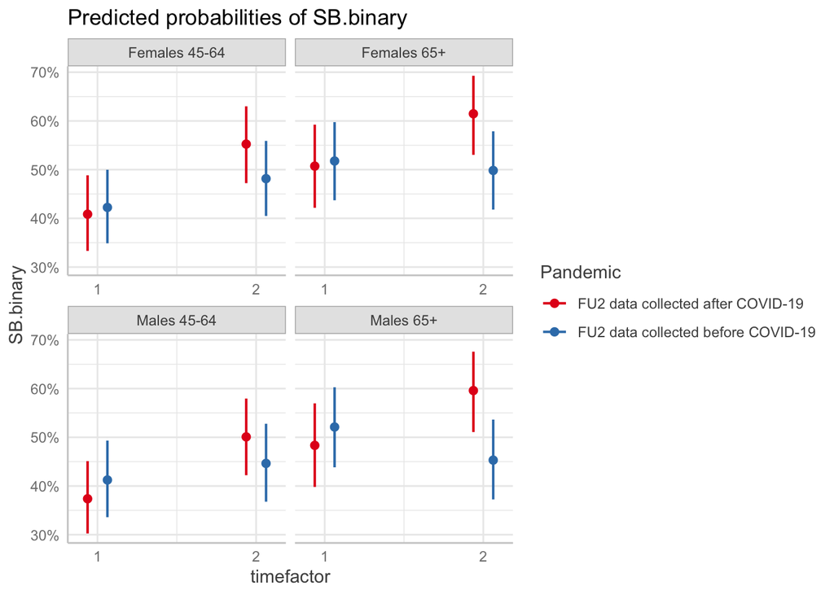

```r
ggpredict(sit2, c("timefactor","Pandemic","Age_sex")) %>% plot()
```

### 8.2.5) Post-hoc comparisons

There were significant differences between Pre- and Post-pandemic cohorts at FU2 for females 65+ and for males 65+ . We now examine whether there significant changes from FU1 to FU2 in the probability of sitting 4+ hours/day between Pre- and Post-pandemic cohorts for females 65+ and males 65+.

Calculating between-cohort changes from FU1 to FU2 for females 65+ and males 65+

```r
####### Females 65+ ###########

#mean difference
mean.diff.Females.Old.1a<-((subset(sit.test2,x==1 & group == "FU2 data collected after COVID-19" & facet == "Females 65+")$predicted -
         subset(sit.test2,x==2 & group == "FU2 data collected after COVID-19" & facet == "Females 65+")$predicted))

mean.diff.Females.Old.1b<-((subset(sit.test2,x==1 & group == "FU2 data collected before COVID-19" & facet == "Females 65+")$predicted -
         subset(sit.test2,x==2 & group == "FU2 data collected before COVID-19" & facet == "Females 65+")$predicted))

mean.Females.Old.change<- mean.diff.Females.Old.1a - mean.diff.Females.Old.1b

#standard error
se.change.Females.Old <-(sqrt(((subset(sit.test2,x==2 & group == "FU2 data collected after COVID-19" & facet == "Females 65+")$standard.error)^2 +
         (subset(sit.test2,x==2 & group == "FU2 data collected after COVID-19" & facet == "Females 65+")$standard.error^2 +
            (subset(sit.test2,x==2 & group == "FU2 data collected before COVID-19" & facet == "Females 65+")$standard.error)^2 +
            (subset(sit.test2,x==2 & group == "FU2 data collected before COVID-19" & facet == "Females 65+")$standard.error)^2 ))/4))

#confidence interval
UL.Females.Old.change<-mean.Females.Old.change + se.change.Females.Old*1.96
LL.Females.Old.change<-mean.Females.Old.change - se.change.Females.Old*1.96

#t-score
t.Females.Old.change<-mean.change/se.change.Females.Old

#degrees of freedom
df.Females.Old <- nrow(Tracking.data_long_2[Tracking.data_long_2$Age_sex == "Females 65+" & !is.na(Tracking.data_long_2$SB.binary), ])/2 - 2


#p-value
p.change.Females.Old <- pt(t.Females.Old.change, df.Females.Old)

####### Males 65+ ###########

#mean difference
mean.diff.Males.Old.1a<-((subset(sit.test2,x==1 & group == "FU2 data collected after COVID-19" & facet == "Males 65+")$predicted -
         subset(sit.test2,x==2 & group == "FU2 data collected after COVID-19" & facet == "Males 65+")$predicted))

mean.diff.Males.Old.1b<-((subset(sit.test2,x==1 & group == "FU2 data collected before COVID-19" & facet == "Males 65+")$predicted -
         subset(sit.test2,x==2 & group == "FU2 data collected before COVID-19" & facet == "Males 65+")$predicted))

mean.Males.Old.change<- mean.diff.Males.Old.1a - mean.diff.Males.Old.1b

#standard error
se.change.Males.Old <-(sqrt(((subset(sit.test2,x==2 & group == "FU2 data collected after COVID-19" & facet == "Males 65+")$standard.error)^2 +
         (subset(sit.test2,x==2 & group == "FU2 data collected after COVID-19" & facet == "Males 65+")$standard.error^2 +
            (subset(sit.test2,x==2 & group == "FU2 data collected before COVID-19" & facet == "Males 65+")$standard.error)^2 +
            (subset(sit.test2,x==2 & group == "FU2 data collected before COVID-19" & facet == "Males 65+")$standard.error)^2 ))/4))

#confidence interval
UL.Males.Old.change<-mean.Males.Old.change + se.change.Males.Old*1.96
LL.Males.Old.change<-mean.Males.Old.change - se.change.Males.Old*1.96

#t-score
t.Males.Old.change<-mean.Males.Old.change/se.change.Males.Old

#degrees of freedom
df.Males.Old <- nrow(Tracking.data_long_2[Tracking.data_long_2$Age_sex == "Males 65+" & !is.na(Tracking.data_long_2$SB.binary), ])/2 - 2


#p-value
p.change.Males.Old <- pt(t.Males.Old.change, df.Males.Old)
```

Estimated between-cohort changes from FU1 to FU2 for females 65+

```r
mean.Females.Old.change #Between-cohort changes from FU1 to FU2
```

```
## [1] -0.1269601
```

```r
LL.Females.Old.change #LL 95% CI
```

```
## [1] -0.2093184
```

```r
UL.Females.Old.change #UL 95% CI
```

```
## [1] -0.04460176
```

```r
p.change.Females.Old #p-value
```

```
## [1] 0.004830616
```

Estimated between-cohort changes from FU1 to FU2 for males 65+

```r
mean.Males.Old.change #Between-cohort changes from FU1 to FU2
```

```
## [1] -0.1805037
```

```r
LL.Males.Old.change #LL 95% CI
```

```
## [1] -0.2634627
```

```r
UL.Males.Old.change #UL 95% CI
```

```
## [1] -0.09754459
```

```r
p.change.Males.Old #p-value
```

```
## [1] 1.047979e-05
```

# 9) Sleep Results

## 9.1) Main effects model adjusted for baseline

### 9.1.1) Model

```r
sleep1 <- glmer(
  RSTLS_Sleep ~ timefactor*Pandemic + Age + Sex + RSTLS_Sleepbaseline + Education + Ethnicity + IncomeLevel + BMI + CESD.10baseline + SmokingStatus +
    Relationshipstatus + Livingstatus + Anxiety + MoodDisord + Chronicconditions +
    (1|ID),
  data = Tracking.data_long_2,
  family = binomial(link = "logit")
)
summary(sleep1)
```

```
## Generalized linear mixed model fit by maximum likelihood (Laplace
##   Approximation) [glmerMod]
##  Family: binomial  ( logit )
## Formula:
## RSTLS_Sleep ~ timefactor * Pandemic + Age + Sex + RSTLS_Sleepbaseline +
##     Education + Ethnicity + IncomeLevel + BMI + CESD.10baseline +
##     SmokingStatus + Relationshipstatus + Livingstatus + Anxiety +
##     MoodDisord + Chronicconditions + (1 | ID)
##    Data: Tracking.data_long_2
##
##      AIC      BIC   logLik deviance df.resid
##  24480.7  24726.9 -12209.4  24418.7    20731
##
## Scaled residuals:
##     Min      1Q  Median      3Q     Max
## -2.1476 -0.5768 -0.4264  0.8300  2.1728
##
## Random effects:
##  Groups Name        Variance Std.Dev.
##  ID     (Intercept) 0.7991   0.8939
## Number of obs: 20762, groups:  ID, 10407
##
## Fixed effects:
##                                                         Estimate Std. Error
## (Intercept)                                            -1.102094   0.240267
## timefactor2                                            -0.184892   0.049079
## PandemicFU2 data collected before COVID-19             -0.010032   0.050741
## Age                                                    -0.011850   0.002318
## SexM                                                   -0.209079   0.042200
## RSTLS_Sleepbaseline                                     0.913108   0.044684
## EducationHigh School Diploma                            0.141962   0.058811
## EducationLess than High School Diploma                  0.219663   0.080621
## EducationSome College                                   0.148389   0.073623
## EthnicityWhite                                          0.160193   0.119557
## IncomeLevel>$150k                                      -0.061071   0.113166
## IncomeLevel$100-150k                                    0.010073   0.088913
## IncomeLevel$20-50k                                     -0.046589   0.057333
## IncomeLevel$50-100k                                     0.009452   0.062245
## BMI                                                     0.001946   0.003807
## CESD.10baseline                                         0.063687   0.005142
```

[output cut: 32 more lines]

```
## SmokingStatusNever Smoked                               -0.800 0.423504
## SmokingStatusOccasional Smoker                          -0.648 0.517259
## RelationshipstatusMarried                               -0.883 0.377387
## RelationshipstatusSeparated                             -2.765 0.005699 **
## RelationshipstatusSingle                                -2.305 0.021182 *
## RelationshipstatusWidowed                               -1.573 0.115709
## LivingstatusAssisted Living                              0.844 0.398872
## LivingstatusHouse                                        2.262 0.023722 *
## LivingstatusOther                                       -0.238 0.812021
## AnxietyYes                                              -1.790 0.073463 .
## MoodDisordYes                                           -0.568 0.570147
## Chronicconditions                                        9.078  < 2e-16 ***
## timefactor2:PandemicFU2 data collected before COVID-19  -0.093 0.925786
## ---
## Signif. codes:  0 '***' 0.001 '**' 0.01 '*' 0.05 '.' 0.1 ' ' 1
```

```
##
## Correlation matrix not shown by default, as p = 30 > 12.
## Use print(x, correlation=TRUE)  or
##     vcov(x)        if you need it
```

```
## optimizer (Nelder_Mead) convergence code: 4 (failure to converge in 10000 evaluations)
## Model failed to converge with max|grad| = 3.47722 (tol = 0.002, component 1)
## Model is nearly unidentifiable: very large eigenvalue
##  - Rescale variables?
## failure to converge in 10000 evaluations
```

```r
anova(sleep1)
```

```
## Analysis of Variance Table
##                     npar Sum Sq Mean Sq  F value
## timefactor             1  25.33   25.33  25.3310
## Pandemic               1   0.20    0.20   0.1970
## Age                    1  11.94   11.94  11.9439
## Sex                    1  70.82   70.82  70.8187
## RSTLS_Sleepbaseline    1 960.43  960.43 960.4277
## Education              3  23.26    7.75   7.7536
## Ethnicity              1   1.26    1.26   1.2609
## IncomeLevel            4   7.18    1.80   1.7954
## BMI                    1  10.21   10.21  10.2091
## CESD.10baseline        1 199.88  199.88 199.8845
## SmokingStatus          3   9.59    3.20   3.1974
## Relationshipstatus     4  14.93    3.73   3.7331
## Livingstatus           3   5.26    1.75   1.7529
## Anxiety                1   1.31    1.31   1.3085
## MoodDisord             1   0.07    0.07   0.0708
## Chronicconditions      1  89.02   89.02  89.0217
## timefactor:Pandemic    1   0.01    0.01   0.0093
```

### 9.1.2) Predicted probabilities

```r
ggpredict(sleep1, c("timefactor", "Pandemic"))
```

```
## # Predicted probabilities of RSTLS_Sleep
##
## Pandemic: FU2 data collected after COVID-19
##
## timefactor | Predicted |     95% CI
## -----------------------------------
## 1          |      0.29 | 0.23, 0.35
## 2          |      0.25 | 0.20, 0.31
##
## Pandemic: FU2 data collected before COVID-19
##
## timefactor | Predicted |     95% CI
## -----------------------------------
## 1          |      0.28 | 0.23, 0.35
## 2          |      0.25 | 0.19, 0.31
##
## Adjusted for:
## *                 Age =                    60.00
## *                 Sex =                        F
## * RSTLS_Sleepbaseline =                     0.33
## *           Education = College Degree or Higher
## *           Ethnicity =                    Other
## *         IncomeLevel =                    <$20k
## *                 BMI =                    27.53
## *     CESD.10baseline =                     4.88
## *       SmokingStatus =             Daily Smoker
## *  Relationshipstatus =                 Divorced
## *        Livingstatus = Apartment/Condo/Townhome
## *             Anxiety =                       No
## *          MoodDisord =                       No
## *   Chronicconditions =                     2.76
## *                  ID =     0 (population-level)
```

### 9.1.3) Estimated Mean Differences Between Pre- and Post-pandemic Cohorts at FU1 and FU2

Calculating estimated mean differences between cohorts

```r
#Create data frame
sleep.test <- as.data.frame(ggpredict(sleep1, c("timefactor", "Pandemic")))

#Determine standard errors
sleep.test$standard.error <- (sleep.test$predicted - sleep.test$conf.low)/1.96

#Calculating estimated mean differences between cohorts at FU1
mean.diff.1a<-(subset(sleep.test,x==1 & group == "FU2 data collected after COVID-19")$predicted -
         subset(sleep.test,x==1 & group == "FU2 data collected before COVID-19")$predicted)

se.1a<-(sqrt(((subset(sleep.test,x==1 & group == "FU2 data collected after COVID-19")$standard.error)^2 +
         (subset(sleep.test,x==1 & group == "FU2 data collected before COVID-19")$standard.error^2))/2))

UL.1a<-mean.diff.1a + se.1a*1.96
LL.1a<-mean.diff.1a - se.1a*1.96


#Calculating estimated mean differences between cohorts at FU2
mean.diff.2a<-(subset(sleep.test,x==2 & group == "FU2 data collected after COVID-19")$predicted -
         subset(sleep.test,x==2 & group == "FU2 data collected before COVID-19")$predicted)

se.2a<-(sqrt(((subset(sleep.test,x==2 & group == "FU2 data collected after COVID-19")$standard.error)^2 +
         (subset(sleep.test,x==2 & group == "FU2 data collected before COVID-19")$standard.error^2))/2))

UL.2a<-mean.diff.2a + se.2a*1.96
LL.2a<-mean.diff.2a - se.2a*1.96


#Calculating z-scores for differences
z.1a<- (subset(sleep.test,x==1 & group == "FU2 data collected after COVID-19")$predicted -
         subset(sleep.test,x==1 & group == "FU2 data collected before COVID-19")$predicted) / (sqrt(((subset(sleep.test,x==1 & group == "FU2 data collected after COVID-19")$standard.error)^2 +
     (subset(sleep.test,x==1 & group == "FU2 data collected before COVID-19")$standard.error^2))/2))

z.2a<- (subset(sleep.test,x==2 & group == "FU2 data collected after COVID-19")$predicted -
         subset(sleep.test,x==2 & group == "FU2 data collected before COVID-19")$predicted) / (sqrt(((subset(sleep.test,x==2 & group == "FU2 data collected after COVID-19")$standard.error)^2 +
         (subset(sleep.test,x==2 & group == "FU2 data collected before COVID-19")$standard.error^2))/2))


#p-values for z-scores
p.1a<-2*pnorm(z.1a, mean = 0, sd = 1, lower.tail = FALSE)
p.2a<-2*pnorm(z.2a, mean = 0, sd = 1, lower.tail = FALSE)
```

Estimated mean differences between cohorts at FU1

```r
mean.diff.1a #mean difference
```

```
## [1] 0.00204652
```

```r
LL.1a #Lower 95% CI
```

```
## [1] -0.05738286
```

```r
UL.1a #Upper 95% CI
```

```
## [1] 0.0614759
```

```r
z.1a # z-score
```

```
## [1] 0.06749489
```

```r
p.1a #p-value
```

```
## [1] 0.9461877
```

Estimated mean differences between cohorts at FU2

```r
mean.diff.2a #mean difference
```

```
## [1] 0.003035537
```

```r
LL.2a #Lower 95% CI
```

```
## [1] -0.05089541
```

```r
UL.2a #Upper 95% CI
```

```
## [1] 0.05696648
```

```r
z.2a # z-score
```

```
## [1] 0.1103198
```

```r
p.2a #p-value
```

```
## [1] 0.9121557
```

### 9.1.4) Graph of predicted probabilities

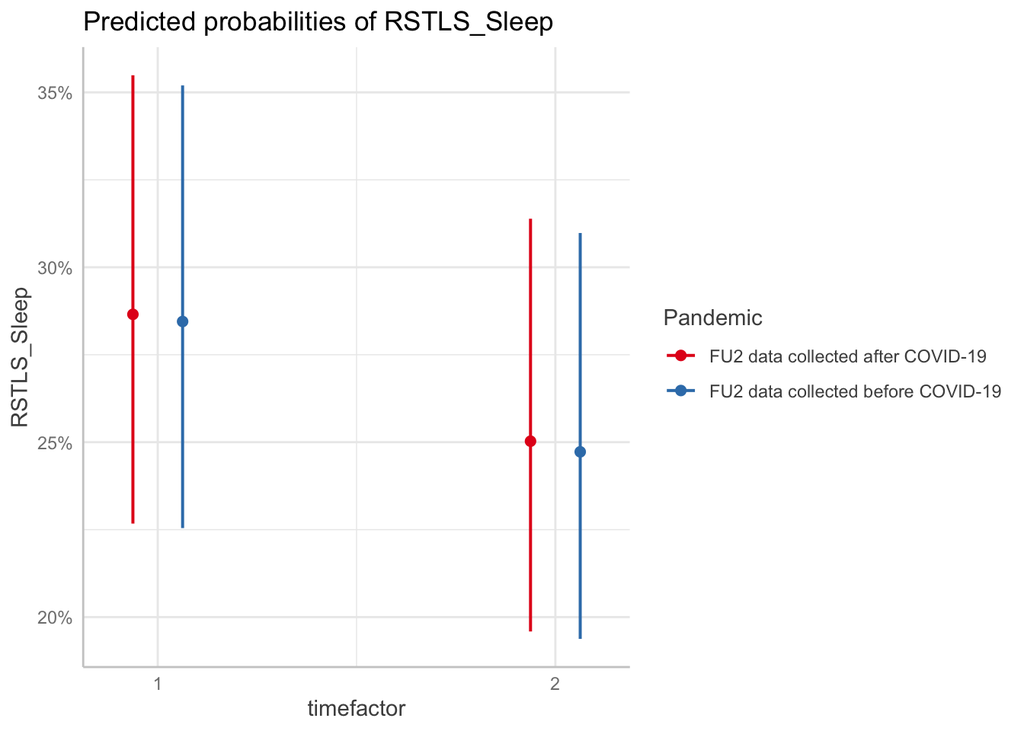

```r
ggpredict(sleep1, c("timefactor", "Pandemic")) %>% plot()
```

### 9.1.5) Post-hoc analysis

There are no significant differences between cohorts, and thus no post-hoc testing.

## 9.2) Age and Sex Interaction Model

### 9.2.1) Model

```r
sleep2 <- glmer(
  RSTLS_Sleep ~ timefactor*Pandemic*Age_sex + RSTLS_Sleepbaseline + Education + Ethnicity + IncomeLevel + BMI + CESD.10baseline + SmokingStatus +
    Relationshipstatus + Livingstatus + Anxiety + MoodDisord + Chronicconditions +
    (1|ID),
  data = Tracking.data_long_2,
  family = binomial(link = "logit")
)
summary(sleep2)
```

```
## Generalized linear mixed model fit by maximum likelihood (Laplace
##   Approximation) [glmerMod]
##  Family: binomial  ( logit )
## Formula: RSTLS_Sleep ~ timefactor * Pandemic * Age_sex + RSTLS_Sleepbaseline +
##     Education + Ethnicity + IncomeLevel + BMI + CESD.10baseline +
##     SmokingStatus + Relationshipstatus + Livingstatus + Anxiety +
##     MoodDisord + Chronicconditions + (1 | ID)
##    Data: Tracking.data_long_2
##
##      AIC      BIC   logLik deviance df.resid
##  24481.7  24807.3 -12199.9  24399.7    20721
##
## Scaled residuals:
##     Min      1Q  Median      3Q     Max
## -2.2534 -0.5763 -0.4240  0.8275  2.3373
##
## Random effects:
##  Groups Name        Variance Std.Dev.
##  ID     (Intercept) 0.8078   0.8988
## Number of obs: 20762, groups:  ID, 10407
##
## Fixed effects:
##                                                                            Estimate
## (Intercept)                                                               -1.671773
## timefactor2                                                               -0.281688
## PandemicFU2 data collected before COVID-19                                -0.155181
## Age_sexFemales 65+                                                        -0.226663
## Age_sexMales 45-64                                                        -0.510486
## Age_sexMales 65+                                                          -0.477572
## RSTLS_Sleepbaseline                                                        0.911139
## EducationHigh School Diploma                                               0.135689
## EducationLess than High School Diploma                                     0.204534
## EducationSome College                                                      0.132670
## EthnicityWhite                                                             0.131442
## IncomeLevel>$150k                                                          0.014420
## IncomeLevel$100-150k                                                       0.077726
## IncomeLevel$20-50k                                                        -0.022403
## IncomeLevel$50-100k                                                        0.037373
## BMI                                                                        0.003336
## CESD.10baseline                                                            0.064369
```

[output cut: 174 more lines]

```
## AnxietyYes
## MoodDisordYes
## Chronicconditions                                                         ***
## timefactor2:PandemicFU2 data collected before COVID-19
## timefactor2:Age_sexFemales 65+
## timefactor2:Age_sexMales 45-64                                            *
## timefactor2:Age_sexMales 65+
## PandemicFU2 data collected before COVID-19:Age_sexFemales 65+
## PandemicFU2 data collected before COVID-19:Age_sexMales 45-64             **
## PandemicFU2 data collected before COVID-19:Age_sexMales 65+
## timefactor2:PandemicFU2 data collected before COVID-19:Age_sexFemales 65+
## timefactor2:PandemicFU2 data collected before COVID-19:Age_sexMales 45-64 *
## timefactor2:PandemicFU2 data collected before COVID-19:Age_sexMales 65+
## ---
## Signif. codes:  0 '***' 0.001 '**' 0.01 '*' 0.05 '.' 0.1 ' ' 1
```

```
##
## Correlation matrix not shown by default, as p = 40 > 12.
## Use print(x, correlation=TRUE)  or
##     vcov(x)        if you need it
```

```
## optimizer (Nelder_Mead) convergence code: 4 (failure to converge in 10000 evaluations)
## Model failed to converge with max|grad| = 3.59238 (tol = 0.002, component 1)
## Model is nearly unidentifiable: very large eigenvalue
##  - Rescale variables?
## failure to converge in 10000 evaluations
```

```r
anova(sleep2)
```

```
## Analysis of Variance Table
##                             npar Sum Sq Mean Sq  F value
## timefactor                     1  26.02   26.02  26.0210
## Pandemic                       1   0.22    0.22   0.2236
## Age_sex                        3  91.71   30.57  30.5712
## RSTLS_Sleepbaseline            1 950.15  950.15 950.1510
## Education                      3  22.41    7.47   7.4687
## Ethnicity                      1   0.97    0.97   0.9700
## IncomeLevel                    4   4.54    1.14   1.1353
## BMI                            1  11.99   11.99  11.9911
## CESD.10baseline                1 203.24  203.24 203.2397
## SmokingStatus                  3   8.11    2.70   2.7025
## Relationshipstatus             4  13.54    3.39   3.3861
## Livingstatus                   3   6.62    2.21   2.2072
## Anxiety                        1   0.71    0.71   0.7068
## MoodDisord                     1   0.13    0.13   0.1324
## Chronicconditions              1  88.62   88.62  88.6201
## timefactor:Pandemic            1   0.00    0.00   0.0018
## timefactor:Age_sex             3   1.24    0.41   0.4143
## Pandemic:Age_sex               3  13.69    4.56   4.5630
## timefactor:Pandemic:Age_sex    3  10.74    3.58   3.5806
```

### 9.2.2) Predicted probabilities

```r
ggpredict(sleep2, c("Pandemic","timefactor","Age_sex"))
```

```
## # Predicted probabilities of RSTLS_Sleep
##
## timefactor: 1
## Age_sex: Females 45-64
##
## Pandemic                           | Predicted |     95% CI
## -----------------------------------------------------------
## FU2 data collected after COVID-19  |      0.32 | 0.26, 0.40
## FU2 data collected before COVID-19 |      0.29 | 0.23, 0.36
##
## timefactor: 1
## Age_sex: Females 65+
##
## Pandemic                           | Predicted |     95% CI
## -----------------------------------------------------------
## FU2 data collected after COVID-19  |      0.28 | 0.21, 0.35
## FU2 data collected before COVID-19 |      0.23 | 0.18, 0.30
##
## timefactor: 1
## Age_sex: Males 45-64
##
## Pandemic                           | Predicted |     95% CI
## -----------------------------------------------------------
## FU2 data collected after COVID-19  |      0.22 | 0.17, 0.29
## FU2 data collected before COVID-19 |      0.26 | 0.20, 0.33
##
## timefactor: 1
## Age_sex: Males 65+
##
## Pandemic                           | Predicted |     95% CI
## -----------------------------------------------------------
## FU2 data collected after COVID-19  |      0.23 | 0.17, 0.30
## FU2 data collected before COVID-19 |      0.23 | 0.17, 0.29
##
## timefactor: 2
## Age_sex: Females 45-64
##
## Pandemic                           | Predicted |     95% CI
## -----------------------------------------------------------
## FU2 data collected after COVID-19  |      0.27 | 0.21, 0.34
```

[output cut: 25 more lines]

```
##
## Adjusted for:
## * RSTLS_Sleepbaseline =                     0.33
## *           Education = College Degree or Higher
## *           Ethnicity =                    Other
## *         IncomeLevel =                    <$20k
## *                 BMI =                    27.53
## *     CESD.10baseline =                     4.88
## *       SmokingStatus =             Daily Smoker
## *  Relationshipstatus =                 Divorced
## *        Livingstatus = Apartment/Condo/Townhome
## *             Anxiety =                       No
## *          MoodDisord =                       No
## *   Chronicconditions =                     2.76
## *                  ID =     0 (population-level)
```

```r
sleep.test2 <- as.data.frame(ggpredict(sleep2, c("timefactor", "Pandemic", "Age_sex")))

sleep.test2$standard.error <- (sleep.test2$predicted - sleep.test2$conf.low)/1.96
```

### 9.2.3) Estimated mean differences between pre- and post-pandemic cohorts by age and sex

Calculating mean differences and 95% CIs for each age/sex group

```r
######### Females 45-64 years #########

#Calculating means and standard errors for females 45-64 years
mean.diff.Females.Young.1a<-(subset(sleep.test2,x==1 & group == "FU2 data collected after COVID-19" & facet == "Females 45-64")$predicted -
                               subset(sleep.test2,x==1 & group == "FU2 data collected before COVID-19" & facet == "Females 45-64")$predicted)

se.Females.Young.1a<-(sqrt(((subset(sleep.test2,x==1 & group == "FU2 data collected after COVID-19" & facet == "Females 45-64")$standard.error)^2 +
                              (subset(sleep.test2,x==1 & group == "FU2 data collected before COVID-19" & facet == "Females 45-64")$standard.error^2))/2))

UL.Females.Young.1a<-mean.diff.Females.Young.1a + se.Females.Young.1a*1.96
LL.Females.Young.1a<-mean.diff.Females.Young.1a - se.Females.Young.1a*1.96

mean.diff.Females.Young.2a<-(subset(sleep.test2,x==2 & group == "FU2 data collected after COVID-19" & facet == "Females 45-64")$predicted -
                               subset(sleep.test2,x==2 & group == "FU2 data collected before COVID-19" & facet == "Females 45-64")$predicted)

se.Females.Young.2a<-(sqrt(((subset(sleep.test2,x==2 & group == "FU2 data collected after COVID-19" & facet == "Females 45-64")$standard.error)^2 +
                              (subset(sleep.test2,x==2 & group == "FU2 data collected before COVID-19" & facet == "Females 45-64")$standard.error^2))/2))

UL.Females.Young.2a<-mean.diff.Females.Young.2a + se.Females.Young.2a*1.96
LL.Females.Young.2a<-mean.diff.Females.Young.2a - se.Females.Young.2a*1.96

#z-scores for females 45-64 years
z.Females.Young.1a <- (subset(sleep.test2,x==1 & group == "FU2 data collected after COVID-19" & facet == "Females 45-64")$predicted -
                         subset(sleep.test2,x==1 & group == "FU2 data collected before COVID-19" & facet == "Females 45-64")$predicted) / (sqrt(((subset(sleep.test2,x==1 & group == "FU2 data collected after COVID-19" & facet == "Females 45-64")$standard.error)^2 +
                                                                                                                                                   (subset(sleep.test2,x==1 & group == "FU2 data collected before COVID-19" & facet == "Females 45-64")$standard.error^2))/2))

z.Females.Young.2a <- (subset(sleep.test2,x==2 & group == "FU2 data collected after COVID-19" & facet == "Females 45-64")$predicted -
                         subset(sleep.test2,x==2 & group == "FU2 data collected before COVID-19" & facet == "Females 45-64")$predicted) / (sqrt(((subset(sleep.test2,x==2 & group == "FU2 data collected after COVID-19" & facet == "Females 45-64")$standard.error)^2 +
                                                                                                                                                   (subset(sleep.test2,x==2 & group == "FU2 data collected before COVID-19" & facet == "Females 45-64")$standard.error^2))/2))

#p-values for females 45-64 years
p.Females.Young.1a<-2*pnorm(z.Females.Young.1a, mean = 0, sd = 1, lower.tail = FALSE)
p.Females.Young.2a<-2*pnorm(z.Females.Young.2a, mean = 0, sd = 1, lower.tail = FALSE)


########### Females 65+ years ###########

#Calculating means and standard errors for females  65+ years
mean.diff.Females.Old.1a<-(subset(sleep.test2,x==1 & group == "FU2 data collected after COVID-19" & facet == "Females 65+")$predicted -
                             subset(sleep.test2,x==1 & group == "FU2 data collected before COVID-19" & facet == "Females 65+")$predicted)

se.Females.Old.1a<-(sqrt(((subset(sleep.test2,x==1 & group == "FU2 data collected after COVID-19" & facet == "Females 65+")$standard.error)^2 +
                            (subset(sleep.test2,x==1 & group == "FU2 data collected before COVID-19" & facet == "Females 65+")$standard.error^2))/2))

UL.Females.Old.1a<-mean.diff.Females.Old.1a + se.Females.Old.1a*1.96
LL.Females.Old.1a<-mean.diff.Females.Old.1a - se.Females.Old.1a*1.96

mean.diff.Females.Old.2a<-(subset(sleep.test2,x==2 & group == "FU2 data collected after COVID-19" & facet == "Females 65+")$predicted -
                             subset(sleep.test2,x==2 & group == "FU2 data collected before COVID-19" & facet == "Females 65+")$predicted)

se.Females.Old.2a<-(sqrt(((subset(sleep.test2,x==2 & group == "FU2 data collected after COVID-19" & facet == "Females 65+")$standard.error)^2 +
                            (subset(sleep.test2,x==2 & group == "FU2 data collected before COVID-19" & facet == "Females 65+")$standard.error^2))/2))

UL.Females.Old.2a<-mean.diff.Females.Old.2a + se.Females.Old.2a*1.96
LL.Females.Old.2a<-mean.diff.Females.Old.2a - se.Females.Old.2a*1.96

#z-scores for females 65+ years
z.Females.Old.1a <- (subset(sleep.test2,x==1 & group == "FU2 data collected after COVID-19" & facet == "Females 65+")$predicted -
                       subset(sleep.test2,x==1 & group == "FU2 data collected before COVID-19" & facet == "Females 65+")$predicted) / (sqrt(((subset(sleep.test2,x==1 & group == "FU2 data collected after COVID-19" & facet == "Females 65+")$standard.error)^2 +
                                                                                                                                               (subset(sleep.test2,x==1 & group == "FU2 data collected before COVID-19" & facet == "Females 65+")$standard.error^2))/2))

z.Females.Old.2a <- (subset(sleep.test2,x==2 & group == "FU2 data collected after COVID-19" & facet == "Females 65+")$predicted -
                       subset(sleep.test2,x==2 & group == "FU2 data collected before COVID-19" & facet == "Females 65+")$predicted) / (sqrt(((subset(sleep.test2,x==2 & group == "FU2 data collected after COVID-19" & facet == "Females 65+")$standard.error)^2 +
                                                                                                                                               (subset(sleep.test2,x==2 & group == "FU2 data collected before COVID-19" & facet == "Females 65+")$standard.error^2))/2))
```

```r
#p-values for females 65+ years
p.Females.Old.1a<-2*pnorm(z.Females.Old.1a, mean = 0, sd = 1, lower.tail = FALSE)
p.Females.Old.2a<-2*pnorm(z.Females.Old.2a, mean = 0, sd = 1, lower.tail = FALSE)



########## Males 45-64 years ###########

#Calculating means and standard errors for males 45-64 years
mean.diff.Males.Young.1a<-(subset(sleep.test2,x==1 & group == "FU2 data collected after COVID-19" & facet == "Males 45-64")$predicted -
                             subset(sleep.test2,x==1 & group == "FU2 data collected before COVID-19" & facet == "Males 45-64")$predicted)

se.Males.Young.1a<-(sqrt(((subset(sleep.test2,x==1 & group == "FU2 data collected after COVID-19" & facet == "Males 45-64")$standard.error)^2 +
                            (subset(sleep.test2,x==1 & group == "FU2 data collected before COVID-19" & facet == "Males 45-64")$standard.error^2))/2))

UL.Males.Young.1a<-mean.diff.Males.Young.1a + se.Males.Young.1a*1.96
LL.Males.Young.1a<-mean.diff.Males.Young.1a - se.Males.Young.1a*1.96

mean.diff.Males.Young.2a<-(subset(sleep.test2,x==2 & group == "FU2 data collected after COVID-19" & facet == "Males 45-64")$predicted -
                             subset(sleep.test2,x==2 & group == "FU2 data collected before COVID-19" & facet == "Males 45-64")$predicted)

se.Males.Young.2a<-(sqrt(((subset(sleep.test2,x==2 & group == "FU2 data collected after COVID-19" & facet == "Males 45-64")$standard.error)^2 +
                            (subset(sleep.test2,x==2 & group == "FU2 data collected before COVID-19" & facet == "Males 45-64")$standard.error^2))/2))

UL.Males.Young.2a<-mean.diff.Males.Young.2a + se.Males.Young.2a*1.96
LL.Males.Young.2a<-mean.diff.Males.Young.2a - se.Males.Young.2a*1.96

#z-scores for males 45-64 years
z.Males.Young.1a <- (subset(sleep.test2,x==1 & group == "FU2 data collected after COVID-19" & facet == "Males 45-64")$predicted -
                       subset(sleep.test2,x==1 & group == "FU2 data collected before COVID-19" & facet == "Males 45-64")$predicted) / (sqrt(((subset(sleep.test2,x==1 & group == "FU2 data collected after COVID-19" & facet == "Males 45-64")$standard.error)^2 +
                                                                                                                                               (subset(sleep.test2,x==1 & group == "FU2 data collected before COVID-19" & facet == "Males 45-64")$standard.error^2))/2))

z.Males.Young.2a <- (subset(sleep.test2,x==2 & group == "FU2 data collected after COVID-19" & facet == "Males 45-64")$predicted -
                       subset(sleep.test2,x==2 & group == "FU2 data collected before COVID-19" & facet == "Males 45-64")$predicted) / (sqrt(((subset(sleep.test2,x==2 & group == "FU2 data collected after COVID-19" & facet == "Males 45-64")$standard.error)^2 +
                                                                                                                                               (subset(sleep.test2,x==2 & group == "FU2 data collected before COVID-19" & facet == "Males 45-64")$standard.error^2))/2))

#p-values for males 45-64 years
p.Males.Young.1a<-2*pnorm(z.Males.Young.1a, mean = 0, sd = 1, lower.tail = TRUE)
p.Males.Young.2a<-2*pnorm(z.Males.Young.2a, mean = 0, sd = 1, lower.tail = FALSE)


########## Males 65+ years ###########

#Calculating means and standard errors for males 65+ years
mean.diff.Males.Old.1a<-(subset(sleep.test2,x==1 & group == "FU2 data collected after COVID-19" & facet == "Males 65+")$predicted -
                           subset(sleep.test2,x==1 & group == "FU2 data collected before COVID-19" & facet == "Males 65+")$predicted)

se.Males.Old.1a<-(sqrt(((subset(sleep.test2,x==1 & group == "FU2 data collected after COVID-19" & facet == "Males 65+")$standard.error)^2 +
                          (subset(sleep.test2,x==1 & group == "FU2 data collected before COVID-19" & facet == "Males 65+")$standard.error^2))/2))

UL.Males.Old.1a<-mean.diff.Males.Old.1a + se.Males.Old.1a*1.96
LL.Males.Old.1a<-mean.diff.Males.Old.1a - se.Males.Old.1a*1.96

mean.diff.Males.Old.2a<-(subset(sleep.test2,x==2 & group == "FU2 data collected after COVID-19" & facet == "Males 65+")$predicted -
                           subset(sleep.test2,x==2 & group == "FU2 data collected before COVID-19" & facet == "Males 65+")$predicted)

se.Males.Old.2a<-(sqrt(((subset(sleep.test2,x==2 & group == "FU2 data collected after COVID-19" & facet == "Males 65+")$standard.error)^2 +
                          (subset(sleep.test2,x==2 & group == "FU2 data collected before COVID-19" & facet == "Males 65+")$standard.error^2))/2))

UL.Males.Old.2a<-mean.diff.Males.Old.2a + se.Males.Old.2a*1.96
LL.Males.Old.2a<-mean.diff.Males.Old.2a - se.Males.Old.2a*1.96

#z-scores for males 65+ years
z.Males.Old.1a <- (subset(sleep.test2,x==1 & group == "FU2 data collected after COVID-19" & facet == "Males 65+")$predicted -
                     subset(sleep.test2,x==1 & group == "FU2 data collected before COVID-19" & facet == "Males 65+")$predicted) / (sqrt(((subset(sleep.test2,x==1 & group == "FU2 data collected after COVID-19" & facet == "Males 65+")$standard.error)^2 +
                                                                                                                                           (subset(sleep.test2,x==1 & group == "FU2 data collected before COVID-19" & facet == "Males 65+")$standard.error^2))/2))

z.Males.Old.2a <- (subset(sleep.test2,x==2 & group == "FU2 data collected after COVID-19" & facet == "Males 65+")$predicted -
                     subset(sleep.test2,x==2 & group == "FU2 data collected before COVID-19" & facet == "Males 65+")$predicted) / (sqrt(((subset(sleep.test2,x==2 & group == "FU2 data collected after COVID-19" & facet == "Males 65+")$standard.error)^2 +
                                                                                                                                           (subset(sleep.test2,x==2 & group == "FU2 data collected before COVID-19" & facet == "Males 65+")$standard.error^2))/2))
```

```r
#p-values for males 65+ years
p.Males.Old.1a<-2*pnorm(z.Males.Old.1a, mean = 0, sd = 1, lower.tail = FALSE)
p.Males.Old.2a<-2*pnorm(z.Males.Old.2a, mean = 0, sd = 1, lower.tail = TRUE)
```

Mean differences and 95% CIs for females 45-64 years at FU1

```r
mean.diff.Females.Young.1a #Estimated mean difference
```

```
## [1] 0.0330407
```

```r
LL.Females.Young.1a #LL CI
```

```
## [1] -0.03193254
```

```r
UL.Females.Young.1a #UL CI
```

```
## [1] 0.09801394
```

```r
z.Females.Young.1a #z-score
```

```
## [1] 0.9967145
```

```r
p.Females.Young.1a #p-value
```

```
## [1] 0.3189031
```

Mean differences and 95% CIs for females 45-64 years at FU2

```r
mean.diff.Females.Young.2a #Estimated mean difference
```

```
## [1] 0.009115943
```

```r
LL.Females.Young.2a #LL CI
```

```
## [1] -0.04908546
```

```r
UL.Females.Young.2a #UL CI
```

```
## [1] 0.06731734
```

```r
z.Females.Young.2a #z-score
```

```
## [1] 0.30699
```

```r
p.Females.Young.2a #p-value
```

```
## [1] 0.758851
```

Mean differences and 95% CIs for females 65+ years at FU1

```r
mean.diff.Females.Old.1a #Estimated mean difference
```

```
## [1] 0.04386866
```

```r
LL.Females.Old.1a #LL CI
```

```
## [1] -0.01636628
```

```r
UL.Females.Old.1a #UL CI
```

```
## [1] 0.1041036
```

```r
z.Females.Old.1a #z-score
```

```
## [1] 1.427454
```

```r
p.Females.Old.1a #p-value
```

```
## [1] 0.1534492
```

Mean differences and 95% CIs for females 65+ years at FU2

```r
mean.diff.Females.Old.2a #Estimated mean difference
```

```
## [1] 0.04418037
```

```r
LL.Females.Old.2a #LL CI
```

```
## [1] -0.01007088
```

```r
UL.Females.Old.2a #UL CI
```

```
## [1] 0.09843162
```

```r
z.Females.Old.2a #z-score
```

```
## [1] 1.596157
```

```r
p.Females.Old.2a #p-value
```

```
## [1] 0.1104537
```

Mean differences and 95% CIs for males 45-64 years at FU1

```r
mean.diff.Males.Young.1a #Estimated mean difference
```

```
## [1] -0.03871951
```

```r
LL.Males.Young.1a #LL CI
```

```
## [1] -0.09486883
```

```r
UL.Males.Young.1a #UL CI
```

```
## [1] 0.0174298
```

```r
z.Males.Young.1a #z-score
```

```
## [1] -1.351579
```

```r
p.Males.Young.1a #p-value
```

```
## [1] 0.17651
```

Mean differences and 95% CIs for males 45-64 years at FU2

```r
mean.diff.Males.Young.2a #Estimated mean difference
```

```
## [1] 0.009469295
```

```r
LL.Males.Young.2a #LL CI
```

```
## [1] -0.04162417
```

```r
UL.Males.Young.2a #UL CI
```

```
## [1] 0.06056276
```

```r
z.Males.Young.2a #z-score
```

```
## [1] 0.3632523
```

```r
p.Males.Young.2a #p-value
```

```
## [1] 0.7164164
```

Mean differences and 95% CIs for males 65+ years at FU1

```r
mean.diff.Males.Old.1a #Estimated mean difference
```

```
## [1] 0.002540603
```

```r
LL.Males.Old.1a #LL CI
```

```
## [1] -0.0536746
```

```r
UL.Males.Old.1a #UL CI
```

```
## [1] 0.0587558
```

```r
z.Males.Old.1a #z-score
```

```
## [1] 0.08858071
```

```r
p.Males.Old.1a #p-value
```

```
## [1] 0.9294151
```

Mean differences and 95% CIs for males 65+ years at FU2 (significant)

```r
mean.diff.Males.Old.2a #Estimated mean difference
```

```
## [1] -0.05110064
```

```r
LL.Males.Old.2a #LL CI
```

```
## [1] -0.09927331
```

```r
UL.Males.Old.2a #UL CI
```

```
## [1] -0.002927962
```

```r
z.Males.Old.2a #z-score
```

```
## [1] -2.07913
```

```r
p.Males.Old.2a #p-value
```

```
## [1] 0.03760541
```

### 9.2.4) Graph of predicted probabilities

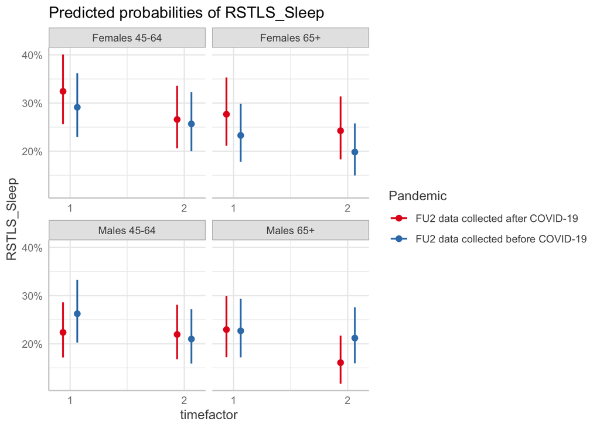

```r
ggpredict(sleep2, c("timefactor","Pandemic","Age_sex")) %>% plot()
```

### 9.2.5) Post-hoc comparisons

Calculating between-cohort changes from FU1 to FU2 for males 65+

```r
####### Males 65+ ###########

#mean difference
mean.diff.Males.Old.1c<-((subset(sleep.test2,x==1 & group == "FU2 data collected after COVID-19" & facet == "Males 65+")$predicted -
         subset(sleep.test2,x==2 & group == "FU2 data collected after COVID-19" & facet == "Males 65+")$predicted))

mean.diff.Males.Old.1d<-((subset(sleep.test2,x==1 & group == "FU2 data collected before COVID-19" & facet == "Males 65+")$predicted -
         subset(sleep.test2,x==2 & group == "FU2 data collected before COVID-19" & facet == "Males 65+")$predicted))

mean.Males.Old.change.1<- mean.diff.Males.Old.1c - mean.diff.Males.Old.1d

#standard error
se.change.Males.Old.1 <-(sqrt(((subset(sleep.test2,x==2 & group == "FU2 data collected after COVID-19" & facet == "Males 65+")$standard.error)^2 +
         (subset(sleep.test2,x==2 & group == "FU2 data collected after COVID-19" & facet == "Males 65+")$standard.error^2 +
            (subset(sleep.test2,x==2 & group == "FU2 data collected before COVID-19" & facet == "Males 65+")$standard.error)^2 +
            (subset(sleep.test2,x==2 & group == "FU2 data collected before COVID-19" & facet == "Males 65+")$standard.error)^2 ))/4))

#confidence interval
UL.Males.Old.change.1<-mean.Males.Old.change.1 + se.change.Males.Old.1*1.96
LL.Males.Old.change.1<-mean.Males.Old.change.1 - se.change.Males.Old.1*1.96

#t-score
t.Males.Old.change.1<-mean.Males.Old.change.1/se.change.Males.Old.1

#degrees of freedom
df.Males.Old.1 <- nrow(Tracking.data_long_2[Tracking.data_long_2$Age_sex == "Males 65+" & !is.na(Tracking.data_long_2$RSTLS_Sleep), ])/2 - 2


#p-value
p.change.Males.Old.1 <- pt(t.Males.Old.change.1, df.Males.Old.1)
```

Estimated between-cohort changes from FU1 to FU2 for males 65+

```r
mean.Males.Old.change.1 #Between-cohort changes from FU1 to FU2
```

```
## [1] 0.05364124
```

```r
LL.Males.Old.change.1 #LL 95% CI
```

```
## [1] 0.005468565
```

```r
UL.Males.Old.change.1 #UL 95% CI
```

```
## [1] 0.1018139
```

```r
p.change.Males.Old.1 #p-value
```

```
## [1] 0.9854057
```

# 10) Changes in lifestyle behaviours associated with changes in cognition

## 10.1) Change score development

Develop change scores in cognition from FU1 to FU2

```r
Tracking.Adjusted_Final$RVLT_Immediate_Change<-Tracking.Adjusted_Final$RVLT_Immediate_Normed_1 - Tracking.Adjusted_Final$RVLT_Immediate_Normed_2 # RVLT Immediate; Lower Scores = Declines
Tracking.Adjusted_Final$RVLT_Delayed_Change<-Tracking.Adjusted_Final$RVLT_Delayed_Normed_1 - Tracking.Adjusted_Final$RVLT_Delayed_Normed_2 # RVLT Delayed; Lower Scores = Declines
Tracking.Adjusted_Final$MAT_Change<-Tracking.Adjusted_Final$MAT_Normed_1 - Tracking.Adjusted_Final$MAT_Normed_2  # MAT; Lower Scores = Declines
Tracking.Adjusted_Final$Animal_Change<-Tracking.Adjusted_Final$Animal_Fluency_Normed_1 - Tracking.Adjusted_Final$Animal_Fluency_Normed_2 # MAT Scores; Lower Score = Declines
```

Develop change scores in Physical Activity

```r
Tracking.Adjusted_Final$PASE_Change<-Tracking.Adjusted_Final$PASE_TOTAL_1 - Tracking.Adjusted_Final$PASE_TOTAL_2
```

Develop change scores in Sedentary Behaviour

```r
Tracking.Adjusted_Final$SB.binary_0 <- as.numeric(ifelse(Tracking.Adjusted_Final$PASE_Q1B_0==10, 1, 0))
Tracking.Adjusted_Final$SB.binary_1 <- as.numeric(ifelse(Tracking.Adjusted_Final$PASE_Q1B_1==10, 1, 0))
Tracking.Adjusted_Final$SB.binary_2 <- as.numeric(ifelse(Tracking.Adjusted_Final$PASE_Q1B_2==10, 1, 0))

Tracking.Adjusted_Final <- Tracking.Adjusted_Final %>%
  mutate(SB_binary_change = case_when(
    Tracking.Adjusted_Final$SB.binary_1 < Tracking.Adjusted_Final$SB.binary_2  ~ 1,
    Tracking.Adjusted_Final$SB.binary_1 > Tracking.Adjusted_Final$SB.binary_2 ~ -1,
    Tracking.Adjusted_Final$SB.binary_1 == Tracking.Adjusted_Final$SB.binary_2 ~ 0)
    )
```

Develop change scores in sleep

```r
Tracking.Adjusted_Final <- Tracking.Adjusted_Final %>%
  mutate(sleep_change = case_when(
    Tracking.Adjusted_Final$RSTLS_Sleep_1 < Tracking.Adjusted_Final$RSTLS_Sleep_2  ~ 1,
    Tracking.Adjusted_Final$RSTLS_Sleep_1 > Tracking.Adjusted_Final$RSTLS_Sleep_2 ~ -1,
    Tracking.Adjusted_Final$RSTLS_Sleep_1 == Tracking.Adjusted_Final$RSTLS_Sleep_2 ~ 0)
    )
```

Age x Sex groups

```r
Tracking.Adjusted_Final$Age_sex<-NA
Tracking.Adjusted_Final$Age_sex[Tracking.Adjusted_Final$Age_0<=64 & Tracking.Adjusted_Final$Sex_0 == "M"]<-"Males 45-64"
Tracking.Adjusted_Final$Age_sex[Tracking.Adjusted_Final$Age_0<=64 & Tracking.Adjusted_Final$Sex_0 == "F"]<-"Females 45-64"
Tracking.Adjusted_Final$Age_sex[Tracking.Adjusted_Final$Age_0>64 & Tracking.Adjusted_Final$Sex_0 == "M"]<-"Males 65+"
Tracking.Adjusted_Final$Age_sex[Tracking.Adjusted_Final$Age_0>64 & Tracking.Adjusted_Final$Sex_0 == "F"]<-"Females 65+"
```

## 10.2) Change score regressions

All regressions are stratified by age group

### 10.2.1) Changes in physical activity associated with changes in cognition

RVLT Immediate

```r
RVLT_immediate_change_model_PA.1<- lm(RVLT_Immediate_Change~PASE_Change*Age_sex, data=subset(Tracking.Adjusted_Final, Pandemic == "FU2 data collected after COVID-19"))
summary(RVLT_immediate_change_model_PA.1)
```

```
##
## Call:
## lm(formula = RVLT_Immediate_Change ~ PASE_Change * Age_sex, data = subset(Tracking.Adjusted_Final,
##     Pandemic == "FU2 data collected after COVID-19"))
##
## Residuals:
##      Min       1Q   Median       3Q      Max
## -11.3843  -2.0480   0.1728   2.3168  10.1583
##
## Coefficients:
##                                 Estimate Std. Error t value Pr(>|t|)
## (Intercept)                    -0.241396   0.363851  -0.663    0.508
## PASE_Change                    -0.003020   0.004974  -0.607    0.544
## Age_sexFemales 65+              0.286761   0.695763   0.412    0.681
## Age_sexMales 45-64             -0.645826   0.502842  -1.284    0.200
## Age_sexMales 65+                0.183342   0.730511   0.251    0.802
## PASE_Change:Age_sexFemales 65+  0.019278   0.014291   1.349    0.178
## PASE_Change:Age_sexMales 45-64  0.006968   0.006767   1.030    0.304
## PASE_Change:Age_sexMales 65+    0.007104   0.013316   0.533    0.594
##
## Residual standard error: 3.739 on 322 degrees of freedom
##   (4851 observations deleted due to missingness)
## Multiple R-squared:  0.02028,    Adjusted R-squared:  -0.001021
## F-statistic: 0.952 on 7 and 322 DF,  p-value: 0.4665
```

```r
anova(RVLT_immediate_change_model_PA.1)
```

```
## Analysis of Variance Table
##
## Response: RVLT_Immediate_Change
##                      Df Sum Sq Mean Sq F value Pr(>F)
## PASE_Change           1    5.8  5.7759  0.4132 0.5208
## Age_sex               3   54.4 18.1434  1.2980 0.2751
## PASE_Change:Age_sex   3   32.9 10.9829  0.7857 0.5026
## Residuals           322 4500.9 13.9781
```

RVLT Delayed

```r
RVLT_delayed_change_model_PA.1<- lm(RVLT_Delayed_Change~PASE_Change*Age_sex, data=subset(Tracking.Adjusted_Final, Pandemic == "FU2 data collected after COVID-19"))
summary(RVLT_delayed_change_model_PA.1)
```

```
##
## Call:
## lm(formula = RVLT_Delayed_Change ~ PASE_Change * Age_sex, data = subset(Tracking.Adjusted_Final,
##     Pandemic == "FU2 data collected after COVID-19"))
##
## Residuals:
##      Min       1Q   Median       3Q      Max
## -12.0894  -2.2134   0.1358   2.2087  10.1317
##
## Coefficients:
##                                 Estimate Std. Error t value Pr(>|t|)
## (Intercept)                    -0.839824   0.349281  -2.404   0.0168 *
## PASE_Change                    -0.002105   0.004772  -0.441   0.6595
## Age_sexFemales 65+              0.495719   0.672882   0.737   0.4618
## Age_sexMales 45-64             -0.214120   0.482270  -0.444   0.6574
## Age_sexMales 65+                1.264534   0.712172   1.776   0.0768 .
## PASE_Change:Age_sexFemales 65+  0.007428   0.013664   0.544   0.5871
## PASE_Change:Age_sexMales 45-64  0.008803   0.006476   1.359   0.1751
## PASE_Change:Age_sexMales 65+   -0.003506   0.012744  -0.275   0.7834
## ---
## Signif. codes:  0 '***' 0.001 '**' 0.01 '*' 0.05 '.' 0.1 ' ' 1
##
## Residual standard error: 3.565 on 314 degrees of freedom
##   (4859 observations deleted due to missingness)
## Multiple R-squared:  0.02424,    Adjusted R-squared:  0.002489
## F-statistic: 1.114 on 7 and 314 DF,  p-value: 0.3536
```

```r
anova(RVLT_delayed_change_model_PA.1)
```

```
## Analysis of Variance Table
##
## Response: RVLT_Delayed_Change
##                      Df Sum Sq Mean Sq F value Pr(>F)
## PASE_Change           1    9.0  8.9787  0.7063 0.4013
## Age_sex               3   60.1 20.0428  1.5766 0.1950
## PASE_Change:Age_sex   3   30.1 10.0208  0.7883 0.5012
## Residuals           314 3991.7 12.7124
```

MAT

```r
MAT_change_model_PA.1<- lm(MAT_Change~PASE_Change*Age_sex, data=subset(Tracking.Adjusted_Final, Pandemic == "FU2 data collected after COVID-19"))
summary(MAT_change_model_PA.1)
```

```
##
## Call:
## lm(formula = MAT_Change ~ PASE_Change * Age_sex, data = subset(Tracking.Adjusted_Final,
##     Pandemic == "FU2 data collected after COVID-19"))
##
## Residuals:
##     Min      1Q  Median      3Q     Max
## -8.5245 -2.3930 -0.4553  1.3800 14.4812
##
## Coefficients:
##                                 Estimate Std. Error t value Pr(>|t|)
## (Intercept)                     2.931067   0.409846   7.152 6.92e-12 ***
## PASE_Change                    -0.008009   0.005520  -1.451    0.148
## Age_sexFemales 65+             -0.243985   0.811992  -0.300    0.764
## Age_sexMales 45-64             -3.231818   0.577223  -5.599 4.98e-08 ***
## Age_sexMales 65+               -3.386889   0.858017  -3.947 9.91e-05 ***
## PASE_Change:Age_sexFemales 65+ -0.027429   0.015973  -1.717    0.087 .
## PASE_Change:Age_sexMales 45-64  0.007257   0.007795   0.931    0.353
## PASE_Change:Age_sexMales 65+    0.015858   0.012792   1.240    0.216
## ---
## Signif. codes:  0 '***' 0.001 '**' 0.01 '*' 0.05 '.' 0.1 ' ' 1
##
## Residual standard error: 4.147 on 292 degrees of freedom
##   (4881 observations deleted due to missingness)
## Multiple R-squared:  0.1333, Adjusted R-squared:  0.1126
## F-statistic: 6.418 on 7 and 292 DF,  p-value: 4.891e-07
```

```r
anova(MAT_change_model_PA.1)
```

```
## Analysis of Variance Table
##
## Response: MAT_Change
##                      Df Sum Sq Mean Sq F value    Pr(>F)
## PASE_Change           1   27.3  27.262  1.5851    0.2090
## Age_sex               3  637.8 212.597 12.3605 1.237e-07 ***
## PASE_Change:Age_sex   3  107.6  35.871  2.0855    0.1022
## Residuals           292 5022.3  17.200
## ---
## Signif. codes:  0 '***' 0.001 '**' 0.01 '*' 0.05 '.' 0.1 ' ' 1
```

Animal Fluency

```r
Animals_change_model_PA.1<- lm(Animal_Change~PASE_Change*Age_sex, data=subset(Tracking.Adjusted_Final, Pandemic == "FU2 data collected after COVID-19"))
summary(Animals_change_model_PA.1)
```

```
##
## Call:
## lm(formula = Animal_Change ~ PASE_Change * Age_sex, data = subset(Tracking.Adjusted_Final,
##     Pandemic == "FU2 data collected after COVID-19"))
##
## Residuals:
##     Min      1Q  Median      3Q     Max
## -8.4504 -1.7331 -0.0457  1.7763  9.3279
##
## Coefficients:
##                                 Estimate Std. Error t value Pr(>|t|)
## (Intercept)                    -0.521225   0.267526  -1.948   0.0522 .
## PASE_Change                     0.002793   0.003652   0.765   0.4450
## Age_sexFemales 65+              0.344951   0.505639   0.682   0.4956
## Age_sexMales 45-64              0.426153   0.371449   1.147   0.2521
## Age_sexMales 65+                0.231333   0.532960   0.434   0.6645
## PASE_Change:Age_sexFemales 65+  0.006526   0.010346   0.631   0.5286
## PASE_Change:Age_sexMales 45-64 -0.005175   0.004990  -1.037   0.3004
## PASE_Change:Age_sexMales 65+   -0.001358   0.008477  -0.160   0.8729
## ---
## Signif. codes:  0 '***' 0.001 '**' 0.01 '*' 0.05 '.' 0.1 ' ' 1
##
## Residual standard error: 2.769 on 326 degrees of freedom
##   (4847 observations deleted due to missingness)
## Multiple R-squared:  0.009762,   Adjusted R-squared:  -0.0115
## F-statistic: 0.4591 on 7 and 326 DF,  p-value: 0.8637
```

```r
anova(Animals_change_model_PA.1)
```

```
## Analysis of Variance Table
##
## Response: Animal_Change
##                      Df  Sum Sq Mean Sq F value Pr(>F)
## PASE_Change           1    0.44  0.4351  0.0568 0.8118
## Age_sex               3    9.24  3.0787  0.4017 0.7519
## PASE_Change:Age_sex   3   14.96  4.9872  0.6507 0.5830
## Residuals           326 2498.77  7.6649
```

### 10.2.2) Changes in sedentary behaviour associated with changes in cognition

RVLT Immediate

```r
RVLT_immediate_change_model_SB.1<- lm(RVLT_Immediate_Change~SB_binary_change*Age_sex, data=subset(Tracking.Adjusted_Final, Pandemic == "FU2 data collected after COVID-19"))
summary(RVLT_immediate_change_model_SB.1)
```

```
##
## Call:
## lm(formula = RVLT_Immediate_Change ~ SB_binary_change * Age_sex,
##     data = subset(Tracking.Adjusted_Final, Pandemic == "FU2 data collected after COVID-19"))
##
## Residuals:
##      Min       1Q   Median       3Q      Max
## -16.5190  -2.2447   0.1054   2.0953  17.3139
##
## Coefficients:
##                                     Estimate Std. Error t value Pr(>|t|)
## (Intercept)                         -0.43243    0.10812  -4.000 6.44e-05 ***
## SB_binary_change                     0.21691    0.17767   1.221 0.222195
## Age_sexFemales 65+                   0.59897    0.18118   3.306 0.000954 ***
## Age_sexMales 45-64                  -0.13149    0.14197  -0.926 0.354377
## Age_sexMales 65+                     0.57052    0.18210   3.133 0.001740 **
## SB_binary_change:Age_sexFemales 65+  0.17550    0.29752   0.590 0.555300
## SB_binary_change:Age_sexMales 45-64 -0.09683    0.23667  -0.409 0.682469
## SB_binary_change:Age_sexMales 65+   -0.54691    0.29915  -1.828 0.067586 .
## ---
## Signif. codes:  0 '***' 0.001 '**' 0.01 '*' 0.05 '.' 0.1 ' ' 1
##
## Residual standard error: 3.944 on 4738 degrees of freedom
##   (435 observations deleted due to missingness)
## Multiple R-squared:  0.007395,   Adjusted R-squared:  0.005928
## F-statistic: 5.043 on 7 and 4738 DF,  p-value: 1.032e-05
```

```r
anova(RVLT_immediate_change_model_SB.1)
```

```
## Analysis of Variance Table
##
## Response: RVLT_Immediate_Change
##                            Df Sum Sq Mean Sq F value    Pr(>F)
## SB_binary_change            1     23  22.836  1.4678    0.2258
## Age_sex                     3    447 149.018  9.5780 2.652e-06 ***
## SB_binary_change:Age_sex    3     79  26.429  1.6987    0.1650
## Residuals                4738  73716  15.558
## ---
## Signif. codes:  0 '***' 0.001 '**' 0.01 '*' 0.05 '.' 0.1 ' ' 1
```

RVLT Delayed

```r
RVLT_delayed_change_model_SB.1<- lm(RVLT_Delayed_Change~SB_binary_change*Age_sex, data=subset(Tracking.Adjusted_Final, Pandemic == "FU2 data collected after COVID-19"))
summary(RVLT_delayed_change_model_SB.1)
```

```
##
## Call:
## lm(formula = RVLT_Delayed_Change ~ SB_binary_change * Age_sex,
##     data = subset(Tracking.Adjusted_Final, Pandemic == "FU2 data collected after COVID-19"))
##
## Residuals:
##      Min       1Q   Median       3Q      Max
## -16.3326  -2.3517   0.3548   2.1454  18.5275
##
## Coefficients:
##                                      Estimate Std. Error t value Pr(>|t|)
## (Intercept)                         -0.829337   0.103732  -7.995 1.62e-15 ***
## SB_binary_change                     0.189118   0.169999   1.112    0.266
## Age_sexFemales 65+                   0.731673   0.175670   4.165 3.17e-05 ***
## Age_sexMales 45-64                  -0.003585   0.136470  -0.026    0.979
## Age_sexMales 65+                     0.836524   0.176279   4.745 2.14e-06 ***
## SB_binary_change:Age_sexFemales 65+  0.251956   0.288403   0.874    0.382
## SB_binary_change:Age_sexMales 45-64 -0.128733   0.227674  -0.565    0.572
## SB_binary_change:Age_sexMales 65+   -0.419324   0.289949  -1.446    0.148
## ---
## Signif. codes:  0 '***' 0.001 '**' 0.01 '*' 0.05 '.' 0.1 ' ' 1
##
## Residual standard error: 3.772 on 4644 degrees of freedom
##   (529 observations deleted due to missingness)
## Multiple R-squared:  0.01039,    Adjusted R-squared:  0.008896
## F-statistic: 6.964 on 7 and 4644 DF,  p-value: 2.817e-08
```

```r
anova(RVLT_delayed_change_model_SB.1)
```

```
## Analysis of Variance Table
##
## Response: RVLT_Delayed_Change
##                            Df Sum Sq Mean Sq F value    Pr(>F)
## SB_binary_change            1     20  19.993  1.4050    0.2359
## Age_sex                     3    611 203.508 14.3015 2.833e-09 ***
## SB_binary_change:Age_sex    3     63  21.055  1.4797    0.2179
## Residuals                4644  66084  14.230
## ---
## Signif. codes:  0 '***' 0.001 '**' 0.01 '*' 0.05 '.' 0.1 ' ' 1
```

MAT

```r
MAT_change_model_SB.1<- lm(MAT_Change~SB_binary_change*Age_sex, data=subset(Tracking.Adjusted_Final, Pandemic == "FU2 data collected after COVID-19"))
summary(MAT_change_model_SB.1)
```

```
##
## Call:
## lm(formula = MAT_Change ~ SB_binary_change * Age_sex, data = subset(Tracking.Adjusted_Final,
##     Pandemic == "FU2 data collected after COVID-19"))
##
## Residuals:
##      Min       1Q   Median       3Q      Max
## -12.9312  -2.6491  -0.5642   1.4569  19.4126
##
## Coefficients:
##                                     Estimate Std. Error t value Pr(>|t|)
## (Intercept)                          3.35159    0.12136  27.616  < 2e-16 ***
## SB_binary_change                    -0.40266    0.19931  -2.020   0.0434 *
## Age_sexFemales 65+                  -0.94495    0.21120  -4.474 7.88e-06 ***
## Age_sexMales 45-64                  -3.39690    0.15990 -21.244  < 2e-16 ***
## Age_sexMales 65+                    -2.99194    0.21571 -13.870  < 2e-16 ***
## SB_binary_change:Age_sexFemales 65+  0.57980    0.34912   1.661   0.0968 .
## SB_binary_change:Age_sexMales 45-64  0.37739    0.26612   1.418   0.1562
## SB_binary_change:Age_sexMales 65+    0.02311    0.35588   0.065   0.9482
## ---
## Signif. codes:  0 '***' 0.001 '**' 0.01 '*' 0.05 '.' 0.1 ' ' 1
##
## Residual standard error: 4.221 on 4104 degrees of freedom
##   (1069 observations deleted due to missingness)
## Multiple R-squared:  0.1148, Adjusted R-squared:  0.1133
## F-statistic: 76.04 on 7 and 4104 DF,  p-value: < 2.2e-16
```

```r
anova(MAT_change_model_SB.1)
```

```
## Analysis of Variance Table
##
## Response: MAT_Change
##                            Df Sum Sq Mean Sq  F value Pr(>F)
## SB_binary_change            1     35   35.08   1.9694 0.1606
## Age_sex                     3   9375 3124.91 175.4260 <2e-16 ***
## SB_binary_change:Age_sex    3     71   23.77   1.3345 0.2612
## Residuals                4104  73106   17.81
## ---
## Signif. codes:  0 '***' 0.001 '**' 0.01 '*' 0.05 '.' 0.1 ' ' 1
```

Animals Fluency

```r
Animals_change_model_SB.1<- lm(Animal_Change~SB_binary_change*Age_sex, data=subset(Tracking.Adjusted_Final, Pandemic == "FU2 data collected after COVID-19"))
summary(Animals_change_model_SB.1)
```

```
##
## Call:
## lm(formula = Animal_Change ~ SB_binary_change * Age_sex, data = subset(Tracking.Adjusted_Final,
##     Pandemic == "FU2 data collected after COVID-19"))
##
## Residuals:
##      Min       1Q   Median       3Q      Max
## -13.3121  -1.8012  -0.0309   1.7468  13.8805
##
## Coefficients:
##                                     Estimate Std. Error t value Pr(>|t|)
## (Intercept)                         -0.25285    0.07641  -3.309 0.000942 ***
## SB_binary_change                    -0.10407    0.12547  -0.829 0.406904
## Age_sexFemales 65+                   0.40158    0.12764   3.146 0.001664 **
## Age_sexMales 45-64                   0.19225    0.10039   1.915 0.055545 .
## Age_sexMales 65+                     0.53293    0.12808   4.161 3.23e-05 ***
## SB_binary_change:Age_sexFemales 65+  0.14482    0.20959   0.691 0.489624
## SB_binary_change:Age_sexMales 45-64  0.06161    0.16761   0.368 0.713184
## SB_binary_change:Age_sexMales 65+    0.13284    0.21084   0.630 0.528677
## ---
## Signif. codes:  0 '***' 0.001 '**' 0.01 '*' 0.05 '.' 0.1 ' ' 1
##
## Residual standard error: 2.798 on 4784 degrees of freedom
##   (389 observations deleted due to missingness)
## Multiple R-squared:  0.004883,   Adjusted R-squared:  0.003427
## F-statistic: 3.353 on 7 and 4784 DF,  p-value: 0.001435
```

```r
anova(Animals_change_model_SB.1)
```

```
## Analysis of Variance Table
##
## Response: Animal_Change
##                            Df Sum Sq Mean Sq F value   Pr(>F)
## SB_binary_change            1      2   2.391  0.3054   0.5805
## Age_sex                     3    176  58.765  7.5052 5.22e-05 ***
## SB_binary_change:Age_sex    3      5   1.704  0.2176   0.8843
## Residuals                4784  37459   7.830
## ---
## Signif. codes:  0 '***' 0.001 '**' 0.01 '*' 0.05 '.' 0.1 ' ' 1
```

### 10.2.3) Changes in sleep associated with changes in cognition

RVLT Immediate

```r
RVLT_immediate_change_model_sleep.1<- lm(RVLT_Immediate_Change~sleep_change*Age_sex, data=subset(Tracking.Adjusted_Final, Pandemic == "FU2 data collected after COVID-19"))
summary(RVLT_immediate_change_model_sleep.1)
```

```
##
## Call:
## lm(formula = RVLT_Immediate_Change ~ sleep_change * Age_sex,
##     data = subset(Tracking.Adjusted_Final, Pandemic == "FU2 data collected after COVID-19"))
##
## Residuals:
##      Min       1Q   Median       3Q      Max
## -16.2153  -2.2548   0.1365   2.0987  17.3321
##
## Coefficients:
##                                 Estimate Std. Error t value Pr(>|t|)
## (Intercept)                      -0.4012     0.1066  -3.762 0.000171 ***
## sleep_change                      0.2802     0.1739   1.612 0.107107
## Age_sexFemales 65+                0.6564     0.1791   3.664 0.000251 ***
## Age_sexMales 45-64               -0.1524     0.1396  -1.091 0.275244
## Age_sexMales 65+                  0.5210     0.1804   2.889 0.003883 **
## sleep_change:Age_sexFemales 65+  -0.2179     0.2932  -0.743 0.457239
## sleep_change:Age_sexMales 45-64  -0.2889     0.2412  -1.198 0.231035
## sleep_change:Age_sexMales 65+    -0.2363     0.3133  -0.754 0.450839
## ---
## Signif. codes:  0 '***' 0.001 '**' 0.01 '*' 0.05 '.' 0.1 ' ' 1
##
## Residual standard error: 3.936 on 4766 degrees of freedom
##   (407 observations deleted due to missingness)
## Multiple R-squared:  0.007259,   Adjusted R-squared:  0.005801
## F-statistic: 4.978 on 7 and 4766 DF,  p-value: 1.252e-05
```

```r
anova(RVLT_immediate_change_model_sleep.1)
```

```
## Analysis of Variance Table
##
## Response: RVLT_Immediate_Change
##                        Df Sum Sq Mean Sq F value    Pr(>F)
## sleep_change            1     13  13.364  0.8625    0.3531
## Age_sex                 3    502 167.444 10.8067 4.494e-07 ***
## sleep_change:Age_sex    3     24   8.086  0.5219    0.6672
## Residuals            4766  73847  15.495
## ---
## Signif. codes:  0 '***' 0.001 '**' 0.01 '*' 0.05 '.' 0.1 ' ' 1
```

RVLT Delayed

```r
RVLT_delayed_change_model_sleep.1<- lm(RVLT_Delayed_Change~sleep_change*Age_sex, data=subset(Tracking.Adjusted_Final, Pandemic == "FU2 data collected after COVID-19"))
summary(RVLT_delayed_change_model_sleep.1)
```

```
##
## Call:
## lm(formula = RVLT_Delayed_Change ~ sleep_change * Age_sex, data = subset(Tracking.Adjusted_Final,
##     Pandemic == "FU2 data collected after COVID-19"))
##
## Residuals:
##      Min       1Q   Median       3Q      Max
## -16.1126  -2.3229   0.1795   2.1602  17.9951
##
## Coefficients:
##                                 Estimate Std. Error t value Pr(>|t|)
## (Intercept)                     -0.78770    0.10252  -7.683 1.88e-14 ***
## sleep_change                     0.32994    0.16738   1.971   0.0488 *
## Age_sexFemales 65+               0.78135    0.17388   4.494 7.17e-06 ***
## Age_sexMales 45-64              -0.04853    0.13456  -0.361   0.7184
## Age_sexMales 65+                 0.80510    0.17467   4.609 4.15e-06 ***
## sleep_change:Age_sexFemales 65+  0.04827    0.28522   0.169   0.8656
## sleep_change:Age_sexMales 45-64 -0.59318    0.23283  -2.548   0.0109 *
## sleep_change:Age_sexMales 65+   -0.31958    0.30429  -1.050   0.2936
## ---
## Signif. codes:  0 '***' 0.001 '**' 0.01 '*' 0.05 '.' 0.1 ' ' 1
##
## Residual standard error: 3.771 on 4669 degrees of freedom
##   (504 observations deleted due to missingness)
## Multiple R-squared:  0.012,  Adjusted R-squared:  0.01051
## F-statistic: 8.098 on 7 and 4669 DF,  p-value: 7.95e-10
```

```r
anova(RVLT_delayed_change_model_sleep.1)
```

```
## Analysis of Variance Table
##
## Response: RVLT_Delayed_Change
##                        Df Sum Sq Mean Sq F value    Pr(>F)
## sleep_change            1      8   8.345  0.5869   0.44365
## Age_sex                 3    677 225.751 15.8773 2.863e-10 ***
## sleep_change:Age_sex    3    120  40.139  2.8230   0.03736 *
## Residuals            4669  66386  14.218
## ---
## Signif. codes:  0 '***' 0.001 '**' 0.01 '*' 0.05 '.' 0.1 ' ' 1
```

MAT

```r
MAT_change_model_sleep.1<- lm(MAT_Change~sleep_change*Age_sex, data=subset(Tracking.Adjusted_Final, Pandemic == "FU2 data collected after COVID-19"))
summary(MAT_change_model_sleep.1)
```

```
##
## Call:
## lm(formula = MAT_Change ~ sleep_change * Age_sex, data = subset(Tracking.Adjusted_Final,
##     Pandemic == "FU2 data collected after COVID-19"))
##
## Residuals:
##      Min       1Q   Median       3Q      Max
## -12.9522  -2.6248  -0.5645   1.4594  19.4475
##
## Coefficients:
##                                 Estimate Std. Error t value Pr(>|t|)
## (Intercept)                      3.31673    0.11985  27.674  < 2e-16 ***
## sleep_change                    -0.04682    0.19468  -0.240    0.810
## Age_sexFemales 65+              -0.88864    0.20935  -4.245 2.24e-05 ***
## Age_sexMales 45-64              -3.36181    0.15752 -21.343  < 2e-16 ***
## Age_sexMales 65+                -2.97402    0.21436 -13.874  < 2e-16 ***
## sleep_change:Age_sexFemales 65+ -0.07449    0.34558  -0.216    0.829
## sleep_change:Age_sexMales 45-64  0.13146    0.27208   0.483    0.629
## sleep_change:Age_sexMales 65+    0.08480    0.37767   0.225    0.822
## ---
## Signif. codes:  0 '***' 0.001 '**' 0.01 '*' 0.05 '.' 0.1 ' ' 1
##
## Residual standard error: 4.22 on 4128 degrees of freedom
##   (1045 observations deleted due to missingness)
## Multiple R-squared:  0.1141, Adjusted R-squared:  0.1125
## F-statistic: 75.92 on 7 and 4128 DF,  p-value: < 2.2e-16
```

```r
anova(MAT_change_model_sleep.1)
```

```
## Analysis of Variance Table
##
## Response: MAT_Change
##                        Df Sum Sq Mean Sq  F value Pr(>F)
## sleep_change            1      3    3.35   0.1883 0.6644
## Age_sex                 3   9451 3150.31 176.9255 <2e-16 ***
## sleep_change:Age_sex    3      8    2.67   0.1501 0.9296
## Residuals            4128  73503   17.81
## ---
## Signif. codes:  0 '***' 0.001 '**' 0.01 '*' 0.05 '.' 0.1 ' ' 1
```

Animal Fluency

```r
Animals_change_model_sleep.1<- lm(Animal_Change~sleep_change*Age_sex, data=subset(Tracking.Adjusted_Final, Pandemic == "FU2 data collected after COVID-19"))
summary(Animals_change_model_sleep.1)
```

```
##
## Call:
## lm(formula = Animal_Change ~ sleep_change * Age_sex, data = subset(Tracking.Adjusted_Final,
##     Pandemic == "FU2 data collected after COVID-19"))
##
## Residuals:
##      Min       1Q   Median       3Q      Max
## -13.1570  -1.7913  -0.0414   1.7570  13.8746
##
## Coefficients:
##                                 Estimate Std. Error t value Pr(>|t|)
## (Intercept)                     -0.26807    0.07580  -3.537 0.000409 ***
## sleep_change                     0.04242    0.12400   0.342 0.732271
## Age_sexFemales 65+               0.40916    0.12675   3.228 0.001255 **
## Age_sexMales 45-64               0.21339    0.09935   2.148 0.031773 *
## Age_sexMales 65+                 0.54635    0.12761   4.282 1.89e-05 ***
## sleep_change:Age_sexFemales 65+ -0.18981    0.20850  -0.910 0.362684
## sleep_change:Age_sexMales 45-64  0.13199    0.17154   0.769 0.441668
## sleep_change:Age_sexMales 65+   -0.11745    0.22216  -0.529 0.597074
## ---
## Signif. codes:  0 '***' 0.001 '**' 0.01 '*' 0.05 '.' 0.1 ' ' 1
##
## Residual standard error: 2.807 on 4810 degrees of freedom
##   (363 observations deleted due to missingness)
## Multiple R-squared:  0.005375,   Adjusted R-squared:  0.003927
## F-statistic: 3.713 on 7 and 4810 DF,  p-value: 0.0005172
```

```r
anova(Animals_change_model_sleep.1)
```

```
## Analysis of Variance Table
##
## Response: Animal_Change
##                        Df Sum Sq Mean Sq F value    Pr(>F)
## sleep_change            1      2   2.017  0.2560    0.6129
## Age_sex                 3    180  59.913  7.6038 4.532e-05 ***
## sleep_change:Age_sex    3     23   7.682  0.9749    0.4035
## Residuals            4810  37900   7.879
## ---
## Signif. codes:  0 '***' 0.001 '**' 0.01 '*' 0.05 '.' 0.1 ' ' 1
```